# IODS course project

# Introduction to Open Data Science - Course Project

Author: Khorloo Batpurev

=======================================================================================================================

# Week 1 - Start to the diary

This course seems like a good fit for me. Even though i am familiar with most of the topics listed, i always find gaps in my knowledge, as i am a self-taught R student. The bits that i am an new to are Git and Rmarkdown. I am looking forward to learning both, so i am planning to get into it with sleeves up.I learnt about the course through Sisu. RHDS is a pretty good option for a crash course i feel. I liked the exercises. Favorite chapter was 4, data visualisation.

#### Github repository

### https://github.com/kbatpurev/IODS-project.git

#### Main outcomes that i hope to achieve

##### Ins and outs of Git and Github

##### Rmarkdown

##### Fill R knowledge gaps

##### And enjoy the course

#### Favourite chapter from RHDS book

Chapter 4 Data Visualisation. I enjoyed the challenge in the exercise to make th European countries life expectancy bar chart.

#### Source of info about course

Through Sisu course menu.

#### Potential proposal to improve the learning outcomes

The fact that R codes are already in the Exercise.Rmd is quite good. But i found myself sometimes glancing over them when i was pressing the Run button. *And therefore I would suggest that part of the assessment or the homework could be to make comments under each code chunk so that students actually have to understand the code and what it is doing*.

#### About this diary

They way i have perceived how this diary should work is to compile learning material that piqued my interest (for example something new, or interesting fact from the course data) rather than jot down everything that i came across the RHDS book.I hope this is an acceptable approach.

#### Getting familiar with gapminder data

```r
library(gapminder)
library(tidyverse)
head(gapminder)
```

```
## # A tibble: 6 × 6
##   country     continent  year lifeExp      pop gdpPercap
##   <fct>       <fct>     <int>   <dbl>    <int>     <dbl>
## 1 Afghanistan Asia       1952    28.8  8425333      779.
## 2 Afghanistan Asia       1957    30.3  9240934      821.
## 3 Afghanistan Asia       1962    32.0 10267083      853.
## 4 Afghanistan Asia       1967    34.0 11537966      836.
## 5 Afghanistan Asia       1972    36.1 13079460      740.
## 6 Afghanistan Asia       1977    38.4 14880372      786.
```

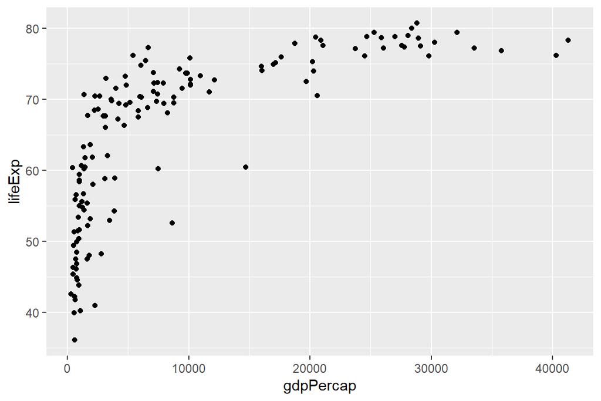

```r
gapminderMongolia=gapminder %>% filter(country=="Mongolia")
#Only 4 fold increase in Mongolia's GPD over 55 years between 1952 and 2007.
#Lets see what Australia looks like
gapminderAustralia=gapminder %>% filter(country=="Australia")
#Only just over 3 folds! Less than Mongolia=Very interesting.
gapminder1997=gapminder%>%filter(year==1997)
gapminder1997%>%ggplot(aes(x=gdpPercap,y=lifeExp))+
  geom_point()
```

```r
t.test(lifeExp~gdpPercap>20000,data=gapminder1997)
```

```
##
##  Welch Two Sample t-test
##
## data:  lifeExp by gdpPercap > 20000
## t = -14.187, df = 137.13, p-value < 2.2e-16
## alternative hypothesis: true difference in means between group FALSE and group TRUE is not equal to 0
## 95 percent confidence interval:
##  -17.59313 -13.28876
## sample estimates:
## mean in group FALSE  mean in group TRUE
##            62.07872            77.51967
```

```r
#Life expectancy in countries with gpd above 20000 (i am guessing USD) is higher than poorer countries. Expected
```

### Week 1 Excercises

### 2.2.4

This was a good little exercise. But to be honest, it would be quite difficult one to solve if you are not familiar with lubridate package or just time/date data generally. Once you understand that, it is quite simple. The example in the RHDS book is quite easy to miss (as it is literally discussed in one code chunk). It required either prior knowledge, or a couple of hours spent going through lubridate.

#### My solution

```r
my_datetime <- ymd_hm("2020-12-01 12:00")
#This enables the characters in the "" to be data/time format. And only then you can start applying functions to it. Before that, it is more like a character and hence R would not understand.
my_datetime %>% class()
```

```
## [1] "POSIXct" "POSIXt"
```

Then I used the same R object in the next bit

```r
current_datetime <- Sys.time()
current_datetime
```

```
## [1] "2023-12-12 21:48:06 AEDT"
```

```r
my_datetime - current_datetime
```

```
## Time difference of -1105.95 days
```

```r
#I didn't want to create another object for the sake of keeping the Environment under control.
my_datesdiff <- my_datetime - current_datetime
my_datesdiff %>% class()
```

```
## [1] "difftime"
```

```r
ymd_hm("2021-01-02 12:00") + my_datesdiff
```

```
## [1] "2017-12-23 13:11:53 UTC"
```

### 4.6.5

As mentioned above, this was my favorite part of the Chapters. Possibly because i love data visualisation generally.I later noticed that the RHDS book solution to the exercise was a bit more elegant than my solution because they went from filtering the data straight to ggplot2 function, whereas i filtered first, then looked at the structure of the data and then applied ggplot2. #### My solution

```r
europe2007=gapminder%>%filter(continent=="Europe",
                              year==2007)
str(europe2007)
```

```
## tibble [30 × 6] (S3: tbl_df/tbl/data.frame)
##  $ country  : Factor w/ 142 levels "Afghanistan",..: 2 7 10 13 16 32 34 35 44 45 ...
##  $ continent: Factor w/ 5 levels "Africa","Americas",..: 4 4 4 4 4 4 4 4 4 4 ...
##  $ year     : int [1:30] 2007 2007 2007 2007 2007 2007 2007 2007 2007 2007 ...
##  $ lifeExp  : num [1:30] 76.4 79.8 79.4 74.9 73 ...
##  $ pop      : int [1:30] 3600523 8199783 10392226 4552198 7322858 4493312 10228744 5468120 5238460 61083916 ...
##  $ gdpPercap: num [1:30] 5937 36126 33693 7446 10681 ...
```

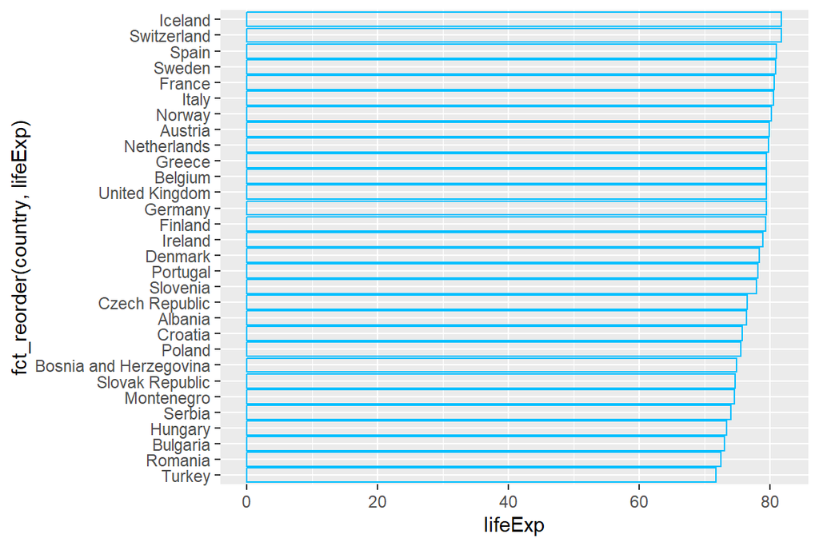

```r
europe2007%>%
  ggplot(aes(y=lifeExp,x=fct_reorder(country,lifeExp)))+
  geom_col(fill=NA,colour="deepskyblue") +
  coord_flip()+
  theme(legend.position = "none")
```

=======================================================================================================================

# Week 2 - Linear Regression

#### **Task 1 - Read student2014 data into R**

```r
setwd("C:/LocalData/batkhor/Coursework/IODS_23/IODS-project/")
student2014<-read.csv("learning2014.csv")
library(tidyverse)
glimpse(student2014)
```

```
## Rows: 166
## Columns: 8
## $ X        <int> 1, 2, 3, 4, 5, 6, 7, 8, 9, 10, 11, 12, 13, 14, 15, 16, 17, 18…
## $ gender   <chr> "F", "M", "F", "M", "M", "F", "M", "F", "M", "F", "M", "F", "…
## $ Age      <int> 53, 55, 49, 53, 49, 38, 50, 37, 37, 42, 37, 34, 34, 34, 35, 3…
## $ attitude <dbl> 3.7, 3.1, 2.5, 3.5, 3.7, 3.8, 3.5, 2.9, 3.8, 2.1, 3.9, 3.8, 2…
## $ deep     <dbl> 3.583333, 2.916667, 3.500000, 3.500000, 3.666667, 4.750000, 3…
## $ stra     <dbl> 3.375, 2.750, 3.625, 3.125, 3.625, 3.625, 2.250, 4.000, 4.250…
## $ surf     <dbl> 2.583333, 3.166667, 2.250000, 2.250000, 2.833333, 2.416667, 1…
## $ Points   <int> 25, 12, 24, 10, 22, 21, 21, 31, 24, 26, 31, 31, 23, 25, 21, 3…
```

**Data dimensions** The dimensions of this dataset should be 166 x 7 (original dimension when created). But reading it back into R using read.csv function adds an ID column at the start, which is titled X because its a blank column name (automated by R) and hence now it has 8 columns instead of 7.

**How this data was created** The original raw data came from: http://www.helsinki.fi/~kvehkala/JYTmooc/JYTOPKYS3-data.txt, which is a tab delimited text file. This was read into R using read.delim2() function (alternatively read.table function). Then 3 groups of questions of interest *Deep questions* = ‘deep’ column,*Strategic questions* = ‘stra’ column and *surface questions* = ‘surf’ column were applied (to select subset of columns from the raw data) and then data was summarised by rowMeans() function for each of the subset of questions. Then we filtered the data so that students with exam points of 0 were eliminated from the dataset using dplyr::filter() function.

#### **Task 2 - Graphical overview**

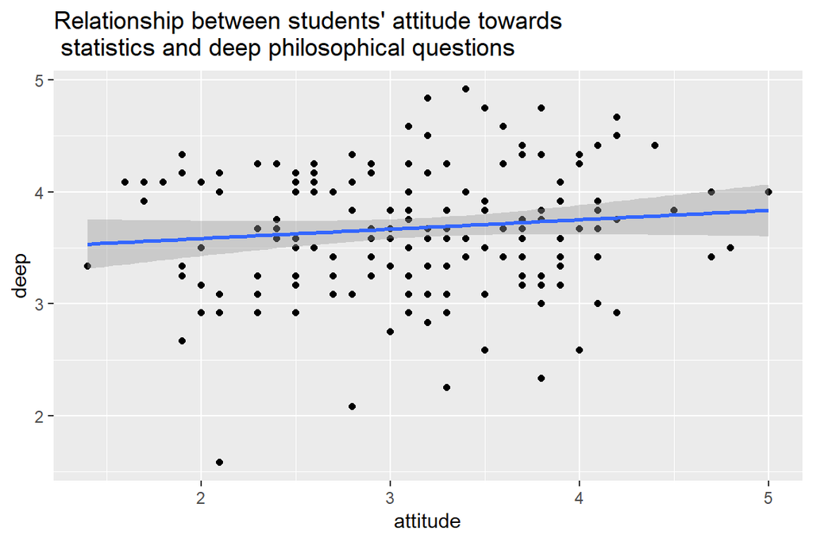

```r
library(ggplot2)
library(GGally)
ggexplore<-ggplot(student2014,aes(x=attitude,y=deep))+
  geom_point()+
  geom_smooth(method = "lm")+
  ggtitle("Relationship between students' attitude towards \n statistics and deep philosophical questions")
ggexplore
```

**Interpretation**: Maybe slight positive relationship, suggesting that people who scored higher on their attitude towards statistics is more likely to score higher on philosophical questions.

##### Pairs plot

This type of plot is great at comparing all the variables against all the others at the same time, rather than plotting only 2 variables at a time with a ggplot+geom_point() function above.

```r
student2014<-student2014[,2:8] #this is needed now because we want the pairs plot to look less messy.
str(student2014)
```

```
## 'data.frame':    166 obs. of  7 variables:
##  $ gender  : chr  "F" "M" "F" "M" ...
##  $ Age     : int  53 55 49 53 49 38 50 37 37 42 ...
##  $ attitude: num  3.7 3.1 2.5 3.5 3.7 3.8 3.5 2.9 3.8 2.1 ...
##  $ deep    : num  3.58 2.92 3.5 3.5 3.67 ...
##  $ stra    : num  3.38 2.75 3.62 3.12 3.62 ...
##  $ surf    : num  2.58 3.17 2.25 2.25 2.83 ...
##  $ Points  : int  25 12 24 10 22 21 21 31 24 26 ...
```

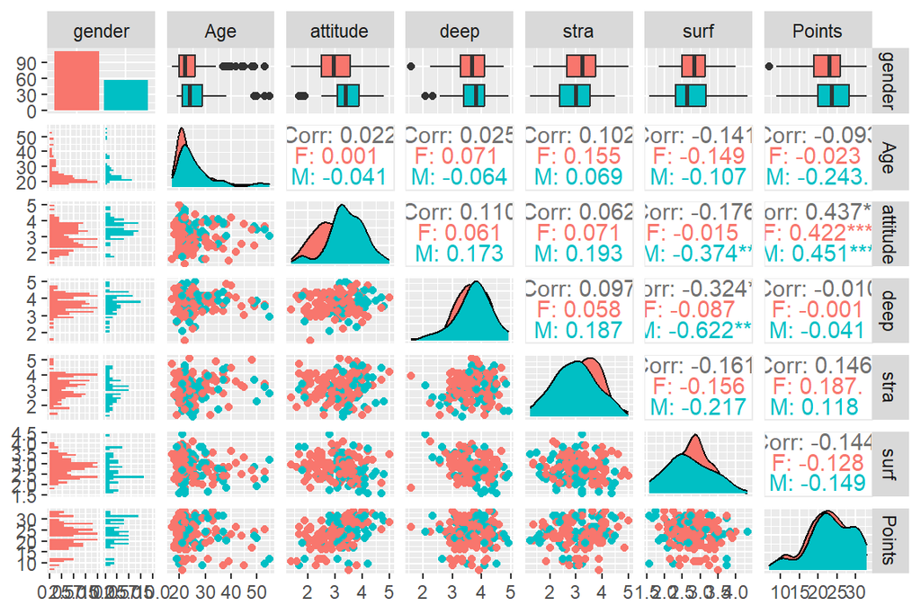

```r
pairs<- ggpairs(student2014, mapping = aes(col=gender), lower = list(combo = wrap("facethist", bins = 30)))
pairs
```

**Interpretation**:

##### A bit deeper

The most significant relationships are between exam points and attitude towards statistics - students with more positive attitude towards statistics are more likely to score higher in exams (perhaps predictable). There is a significant (negative slope) relationship between responses to deep philosophical questions and surface questions - when people score higher on deep questions, they are likely to score lower on surface questions. This relationship is particularly noticeable amongst males. Similar, but weaker relation is true for surface question responses and strategic responses (but no difference in responses between genders).

#### **Task 3 - Regression on exam score**

```r
str(student2014)
```

```
## 'data.frame':    166 obs. of  7 variables:
##  $ gender  : chr  "F" "M" "F" "M" ...
##  $ Age     : int  53 55 49 53 49 38 50 37 37 42 ...
##  $ attitude: num  3.7 3.1 2.5 3.5 3.7 3.8 3.5 2.9 3.8 2.1 ...
##  $ deep    : num  3.58 2.92 3.5 3.5 3.67 ...
##  $ stra    : num  3.38 2.75 3.62 3.12 3.62 ...
##  $ surf    : num  2.58 3.17 2.25 2.25 2.83 ...
##  $ Points  : int  25 12 24 10 22 21 21 31 24 26 ...
```

```r
mod1<-lm(formula= Points ~ attitude+Age+deep+stra+surf,data=student2014)
summary(mod1)
```

```
##
## Call:
## lm(formula = Points ~ attitude + Age + deep + stra + surf, data = student2014)
##
## Residuals:
##      Min       1Q   Median       3Q      Max
## -17.4759  -3.2812   0.3804   3.5381  11.4897
##
## Coefficients:
##             Estimate Std. Error t value Pr(>|t|)
## (Intercept) 18.30059    5.24076   3.492  0.00062 ***
## attitude     3.43200    0.56991   6.022 1.14e-08 ***
## Age         -0.09650    0.05335  -1.809  0.07234 .
## deep        -1.04374    0.78179  -1.335  0.18375
## stra         0.96551    0.53917   1.791  0.07523 .
## surf        -1.10529    0.84009  -1.316  0.19016
## ---
## Signif. codes:  0 '***' 0.001 '**' 0.01 '*' 0.05 '.' 0.1 ' ' 1
##
## Residual standard error: 5.249 on 160 degrees of freedom
## Multiple R-squared:  0.2311, Adjusted R-squared:  0.2071
## F-statistic:  9.62 on 5 and 160 DF,  p-value: 4.803e-08
```

Surface and deep questions don’t have any significant relationship with exam points. So lets remove them, but before that we can be fancy and use a formal variable selection package to confirm our suspesions/support our decision.

```r
library(olsrr)
ols_step_all_possible(mod1)
```

```
##    Index N                  Predictors     R-Square Adj. R-Square Mallow's Cp
## 1      1 1                    attitude 0.1905536672   0.185618019    6.444236
## 4      2 1                        stra 0.0213517768   0.015384410   41.654826
## 5      3 1                        surf 0.0208387755   0.014868280   41.761581
## 2      4 1                         Age 0.0086844365   0.002639829   44.290875
## 3      5 1                        deep 0.0001029919  -0.005993941   46.076658
## 8      6 2               attitude stra 0.2048096617   0.195052725    5.477591
## 6      7 2                attitude Age 0.2011434849   0.191341564    6.240515
## 9      8 2               attitude surf 0.1952865878   0.185412804    7.459324
## 7      9 2               attitude deep 0.1939911024   0.184101423    7.728912
## 15    10 2                   stra surf 0.0363412029   0.024517169   40.535555
## 12    11 2                    Age surf 0.0340077514   0.022155086   41.021142
## 11    12 2                    Age stra 0.0331743748   0.021311484   41.194566
## 14    13 2                   deep surf 0.0244545065   0.012484623   43.009154
## 13    14 2                   deep stra 0.0219453518   0.009944681   43.531304
```

[output cut: 17 more lines]

##### **All possible regression** method

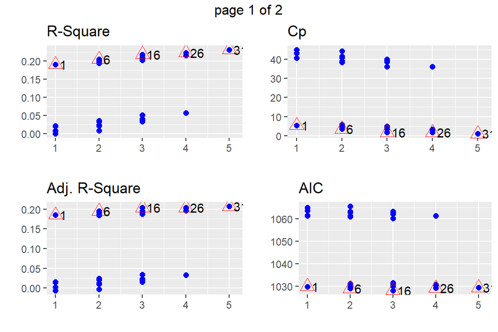

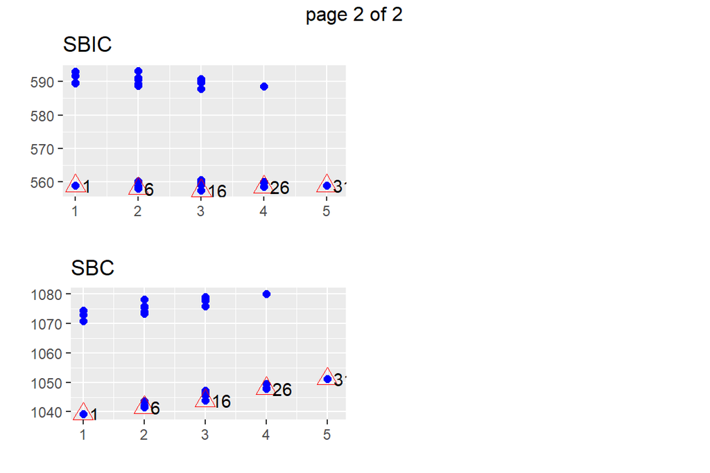

```r
kplot<-ols_step_all_possible(mod1)
plot(kplot)
```

The convention with model stats is usually maximise R-squared and minimise AIC and MSE. But for the best subset of variables, the package has readily made function, which we will try below.

```r
ols_step_best_subset(mod1)
```

```
##          Best Subsets Regression
## ------------------------------------------
## Model Index    Predictors
## ------------------------------------------
##      1         attitude
##      2         attitude stra
##      3         attitude Age stra
##      4         attitude Age deep stra
##      5         attitude Age deep stra surf
## ------------------------------------------
##
##                                                      Subsets Regression Summary
## -------------------------------------------------------------------------------------------------------------------------------------
##                        Adj.        Pred
## Model    R-Square    R-Square    R-Square     C(p)        AIC         SBIC         SBC         MSEP         FPE       HSP       APC
## -------------------------------------------------------------------------------------------------------------------------------------
##   1        0.1906      0.1856      0.1701    6.4442    1029.9875    558.8415    1039.3235    4697.7198    28.6404    0.1736    0.8292
##   2        0.2048      0.1951      0.1785    5.4776    1029.0379    557.9692    1041.4858    4643.4709    28.4772    0.1727    0.8245
##   3        0.2182      0.2037      0.1764    4.6969    1028.2247    557.2987    1043.7847    4593.7993    28.3381    0.1719    0.8204
##   4        0.2228      0.2035      0.1715    5.7310    1029.2363    558.4113    1047.9082    4595.0677    28.5116    0.1730    0.8255
##   5        0.2311      0.2071      0.1677    6.0000    1029.4500    558.8096    1051.2339    4574.4766    28.5487    0.1733    0.8265
## -------------------------------------------------------------------------------------------------------------------------------------
## AIC: Akaike Information Criteria
##  SBIC: Sawa's Bayesian Information Criteria
##  SBC: Schwarz Bayesian Criteria
##  MSEP: Estimated error of prediction, assuming multivariate normality
##  FPE: Final Prediction Error
##  HSP: Hocking's Sp
##  APC: Amemiya Prediction Criteria
```

LOL, more regression summary statistics than i care for! Lets try plotting this so its a bit more intuitive.

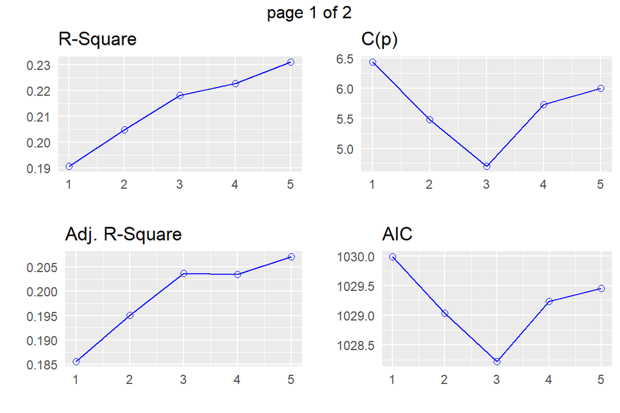

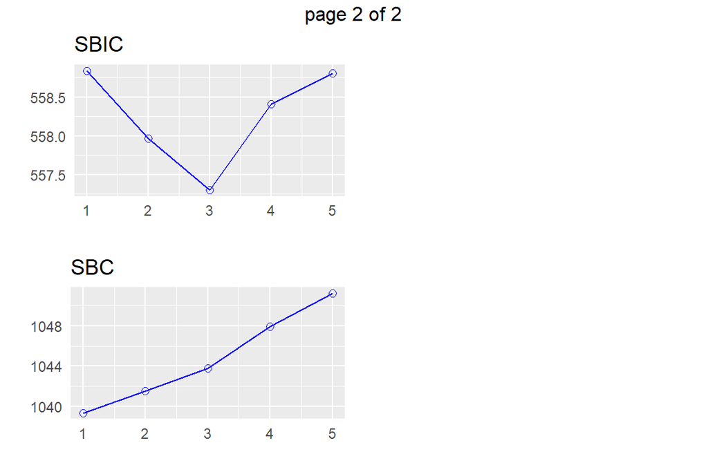

```r
kplot1<-ols_step_best_subset(mod1)
plot(kplot1)
```

##### **Stepwise backward regression** methods

```r
mod2<-lm(formula= Points ~ .,data=student2014)
summary(mod2)
```

```
##
## Call:
## lm(formula = Points ~ ., data = student2014)
##
## Residuals:
##      Min       1Q   Median       3Q      Max
## -17.4506  -3.2479   0.3879   3.5243  11.4820
##
## Coefficients:
##             Estimate Std. Error t value Pr(>|t|)
## (Intercept) 18.30246    5.25723   3.481 0.000644 ***
## genderM     -0.05858    0.92985  -0.063 0.949845
## Age         -0.09607    0.05396  -1.780 0.076929 .
## attitude     3.44300    0.59776   5.760 4.24e-08 ***
## deep        -1.04279    0.78438  -1.329 0.185606
## stra         0.95871    0.55150   1.738 0.084083 .
## surf        -1.10891    0.84467  -1.313 0.191132
## ---
## Signif. codes:  0 '***' 0.001 '**' 0.01 '*' 0.05 '.' 0.1 ' ' 1
##
## Residual standard error: 5.265 on 159 degrees of freedom
## Multiple R-squared:  0.2312, Adjusted R-squared:  0.2021
## F-statistic: 7.967 on 6 and 159 DF,  p-value: 1.599e-07
```

```r
#Notice slightly different function. This is choosing models on AIC.
ols_step_backward_aic(mod2)
```

```
##
##
##                       Backward Elimination Summary
## ----------------------------------------------------------------------
## Variable        AIC         RSS        Sum Sq      R-Sq      Adj. R-Sq
## ----------------------------------------------------------------------
## Full Model    1031.446    4408.344    1325.349    0.23115      0.20214
## gender        1029.450    4408.454    1325.239    0.23113      0.20710
## surf          1029.236    4456.149    1277.544    0.22281      0.20350
## deep          1028.225    4482.762    1250.931    0.21817      0.20369
## ----------------------------------------------------------------------
```

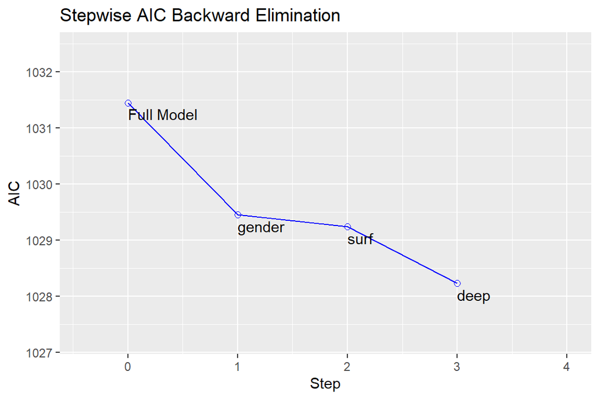

```r
kplot2<-ols_step_backward_aic(mod2)
plot(kplot2)
```

```r
#If we do it based on p value,
ols_step_backward_p(mod2)
```

```
##
##
##                            Elimination Summary
## -------------------------------------------------------------------------
##         Variable                  Adj.
## Step    Removed     R-Square    R-Square     C(p)        AIC        RMSE
## -------------------------------------------------------------------------
##    1    gender        0.2311      0.2071    5.0040    1029.4500    5.2491
## -------------------------------------------------------------------------
```

```r
#Only removes gender from the model, which is slightly different to backward selection based on AIC
```

The results of the step_backward_aic method matches with the best selection method above. I’d be happy to go with that. Hence the final model of choice based on the above two methods is below in final<-lm:

#### **Task 4 - Model interpretation**

```r
final<-lm(formula= Points ~ attitude+Age+stra,data=student2014)
summary(final)
```

```
##
## Call:
## lm(formula = Points ~ attitude + Age + stra, data = student2014)
##
## Residuals:
##      Min       1Q   Median       3Q      Max
## -18.1149  -3.2003   0.3303   3.4129  10.7599
##
## Coefficients:
##             Estimate Std. Error t value Pr(>|t|)
## (Intercept) 10.89543    2.64834   4.114 6.17e-05 ***
## attitude     3.48077    0.56220   6.191 4.72e-09 ***
## Age         -0.08822    0.05302  -1.664   0.0981 .
## stra         1.00371    0.53434   1.878   0.0621 .
## ---
## Signif. codes:  0 '***' 0.001 '**' 0.01 '*' 0.05 '.' 0.1 ' ' 1
##
## Residual standard error: 5.26 on 162 degrees of freedom
## Multiple R-squared:  0.2182, Adjusted R-squared:  0.2037
## F-statistic: 15.07 on 3 and 162 DF,  p-value: 1.07e-08
```

**Call:** This is the function that we are calling. Our final model that we are going to dissect below

**Residuals:** This tells us how well the model fits to the data. It tells us the distance of points away from the main regression line at 5 different places: Minimum, maximum, median, 1st quartile and 3rd quartile (all in units of distancee, rather than actual value).

**Signif.codes:** These relate to significance levels of p-value. Triple star means most significant, dots and space means less significant.

**Model fit stats** Stuff below the significance levels are about model performance statistics. The main one i look at is R-squared values (how much of the variance in the data did the model explain?). In this case its only around 20% - which is quite underwhelming. The difference between the multiple and adjusted R-squared is when penalty is applied to the number of independent variables included in the model. Ideally, we want R-squared values (particularly adjusted R-squared) value closer to 1, which would mean nearly all variability in data is explained by the model.

#### **Task 5 - Diagnostics**

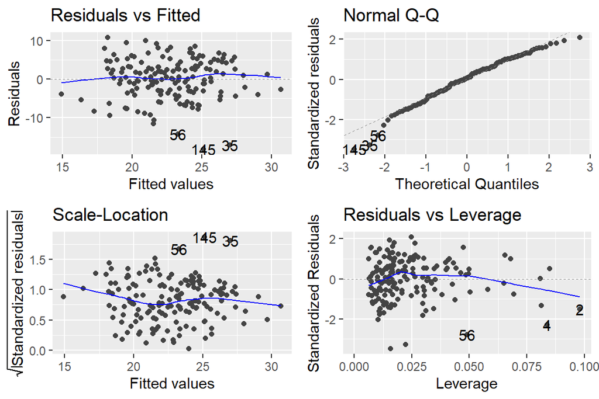

```r
library(ggfortify)
autoplot(final)
```

**Residuals vs Fitted** This shows if the residuals of the model have a normal distribution. If there are abnormal shapes (such as fanning, or curves), that usually indicates that the residuals aren’t normally distributed and therefore the model does not comply with the assumptions of the model (in linear regression this is a must). In this instance, it don’t see any fanning or curving, so that’s fine.

**Normal QQ plot** In this plot, we want to points to be perfectly aligned to the diagonal line, which would indicate a perfect fit. In our case, there are some parts of the data that does large deviation, which means model fit is not very good at the extreme ends. Particular outliers stand out, 56, 145 and 35 are row ids for some special cases in our data set. They do not comply well to the regression line!

**Residuals vs Leverage** This tells us about influence of individual data points (called leverage). Here, data points 4 and 2 (pulling the fitted line at one end) are big influencers (highest leverage). 56 is kind of in the middle, but very much an outlier still (from QQ plot).

=======================================================================================================================

#### **Task 1 - Read student2014 data into R**

```r
knitr::opts_chunk$set(echo = TRUE)
student2014<-read.csv("learning2014.csv")
library(tidyverse)
glimpse(student2014)
```

```
## Rows: 166
## Columns: 8
## $ X        <int> 1, 2, 3, 4, 5, 6, 7, 8, 9, 10, 11, 12, 13, 14, 15, 16, 17, 18…
## $ gender   <chr> "F", "M", "F", "M", "M", "F", "M", "F", "M", "F", "M", "F", "…
## $ Age      <int> 53, 55, 49, 53, 49, 38, 50, 37, 37, 42, 37, 34, 34, 34, 35, 3…
## $ attitude <dbl> 3.7, 3.1, 2.5, 3.5, 3.7, 3.8, 3.5, 2.9, 3.8, 2.1, 3.9, 3.8, 2…
## $ deep     <dbl> 3.583333, 2.916667, 3.500000, 3.500000, 3.666667, 4.750000, 3…
## $ stra     <dbl> 3.375, 2.750, 3.625, 3.125, 3.625, 3.625, 2.250, 4.000, 4.250…
## $ surf     <dbl> 2.583333, 3.166667, 2.250000, 2.250000, 2.833333, 2.416667, 1…
## $ Points   <int> 25, 12, 24, 10, 22, 21, 21, 31, 24, 26, 31, 31, 23, 25, 21, 3…
```

**Data dimensions** The dimensions of this dataset should be 166 x 7 (original dimension when created). But reading it back into R using read.csv function adds an ID column at the start, which is titled X because its a blank column name (automated by R) and hence now it has 8 columns instead of 7.

**How this data was created** The original raw data came from: http://www.helsinki.fi/~kvehkala/JYTmooc/JYTOPKYS3-data.txt, which is a tab delimited text file. This was read into R using read.delim2() function (alternatively read.table function). Then 3 groups of questions of interest *Deep questions* = ‘deep’ column,*Strategic questions* = ‘stra’ column and *surface questions* = ‘surf’ column were applied (to select subset of columns from the raw data) and then data was summarised by rowMeans() function for each of the subset of questions. Then we filtered the data so that students with exam points of 0 were eliminated from the dataset using dplyr::filter() function.

#====================================================================================================================

#### **Task 2 - Graphical overview**

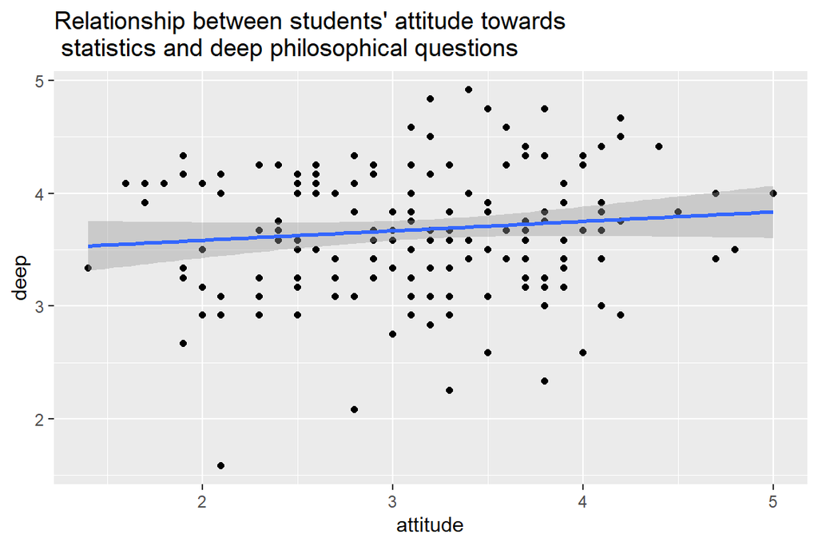

```r
library(ggplot2)
library(GGally)

ggexplore<-ggplot(student2014,aes(x=attitude,y=deep))+
  geom_point()+
  geom_smooth(method = "lm")+
  ggtitle("Relationship between students' attitude towards \n statistics and deep philosophical questions")
ggexplore
```

**Interpretation**: Maybe slight positive relationship, suggesting that people who scored higher on their attitude towards statistics is more likely to score higher on philosophical questions.

##### Pairs plot

This type of plot is great at comparing all the variables against all the others at the same time, rather than plotting only 2 variables at a time with a ggplot+geom_point() function above.

```r
student2014<-student2014[,2:8] #this is needed now because we want the pairs plot to look less messy.
str(student2014)
```

```
## 'data.frame':    166 obs. of  7 variables:
##  $ gender  : chr  "F" "M" "F" "M" ...
##  $ Age     : int  53 55 49 53 49 38 50 37 37 42 ...
##  $ attitude: num  3.7 3.1 2.5 3.5 3.7 3.8 3.5 2.9 3.8 2.1 ...
##  $ deep    : num  3.58 2.92 3.5 3.5 3.67 ...
##  $ stra    : num  3.38 2.75 3.62 3.12 3.62 ...
##  $ surf    : num  2.58 3.17 2.25 2.25 2.83 ...
##  $ Points  : int  25 12 24 10 22 21 21 31 24 26 ...
```

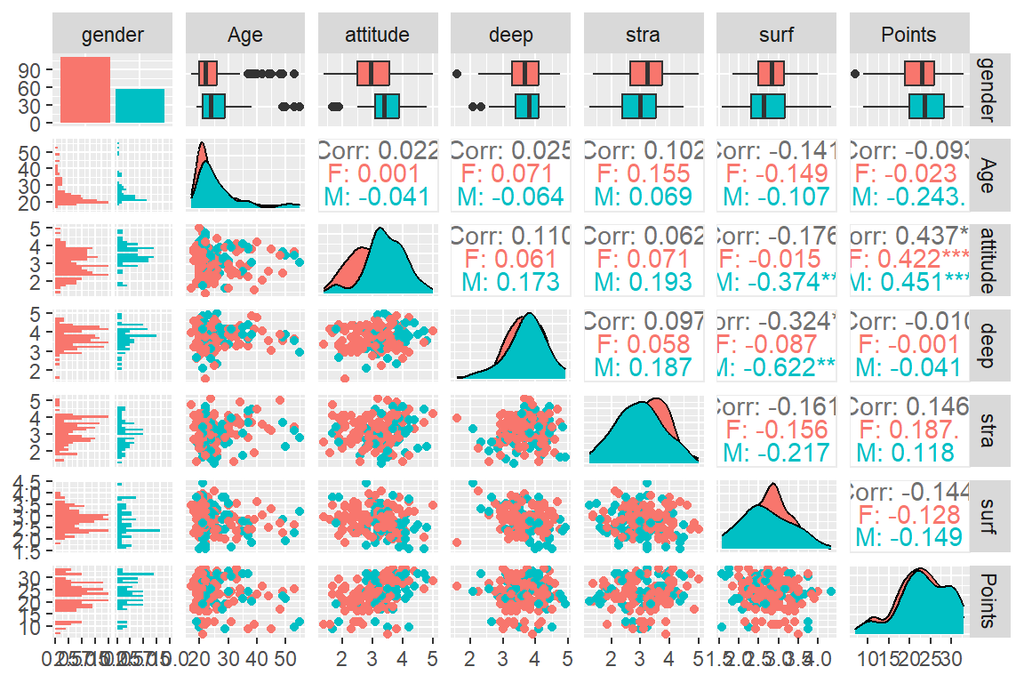

```r
pairs<- ggpairs(student2014, mapping = aes(col=gender), lower = list(combo = wrap("facethist", bins = 30)))
pairs
```

**Interpretation**:

##### A bit deeper

The most significant relationships are between exam points and attitude towards statistics - students with more positive attitude towards statistics are more likely to score higher in exams (perhaps predictable). There is a significant (negative slope) relationship between responses to deep philosophical questions and surface questions - when people score higher on deep questions, they are likely to score lower on surface questions. This relationship is particularly noticeable amongst males. Similar, but weaker relation is true for surface question responses and strategic responses (but no difference in responses between genders).

#====================================================================================================================

#### **Task 3 - Regression on exam score**

```r
str(student2014)
```

```
## 'data.frame':    166 obs. of  7 variables:
##  $ gender  : chr  "F" "M" "F" "M" ...
##  $ Age     : int  53 55 49 53 49 38 50 37 37 42 ...
##  $ attitude: num  3.7 3.1 2.5 3.5 3.7 3.8 3.5 2.9 3.8 2.1 ...
##  $ deep    : num  3.58 2.92 3.5 3.5 3.67 ...
##  $ stra    : num  3.38 2.75 3.62 3.12 3.62 ...
##  $ surf    : num  2.58 3.17 2.25 2.25 2.83 ...
##  $ Points  : int  25 12 24 10 22 21 21 31 24 26 ...
```

```r
mod1<-lm(formula= Points ~ attitude+Age+deep+stra+surf,data=student2014)
summary(mod1)
```

```
##
## Call:
## lm(formula = Points ~ attitude + Age + deep + stra + surf, data = student2014)
##
## Residuals:
##      Min       1Q   Median       3Q      Max
## -17.4759  -3.2812   0.3804   3.5381  11.4897
##
## Coefficients:
##             Estimate Std. Error t value Pr(>|t|)
## (Intercept) 18.30059    5.24076   3.492  0.00062 ***
## attitude     3.43200    0.56991   6.022 1.14e-08 ***
## Age         -0.09650    0.05335  -1.809  0.07234 .
## deep        -1.04374    0.78179  -1.335  0.18375
## stra         0.96551    0.53917   1.791  0.07523 .
## surf        -1.10529    0.84009  -1.316  0.19016
## ---
## Signif. codes:  0 '***' 0.001 '**' 0.01 '*' 0.05 '.' 0.1 ' ' 1
##
## Residual standard error: 5.249 on 160 degrees of freedom
## Multiple R-squared:  0.2311, Adjusted R-squared:  0.2071
## F-statistic:  9.62 on 5 and 160 DF,  p-value: 4.803e-08
```

Surface and deep questions don’t have any significant relationship with exam points. So lets remove them, but before that we can be fancy and use a formal variable selection package to confirm our suspesions/support our decision.

```r
library(olsrr)
ols_step_all_possible(mod1)
```

```
##    Index N                  Predictors     R-Square Adj. R-Square Mallow's Cp
## 1      1 1                    attitude 0.1905536672   0.185618019    6.444236
## 4      2 1                        stra 0.0213517768   0.015384410   41.654826
## 5      3 1                        surf 0.0208387755   0.014868280   41.761581
## 2      4 1                         Age 0.0086844365   0.002639829   44.290875
## 3      5 1                        deep 0.0001029919  -0.005993941   46.076658
## 8      6 2               attitude stra 0.2048096617   0.195052725    5.477591
## 6      7 2                attitude Age 0.2011434849   0.191341564    6.240515
## 9      8 2               attitude surf 0.1952865878   0.185412804    7.459324
## 7      9 2               attitude deep 0.1939911024   0.184101423    7.728912
## 15    10 2                   stra surf 0.0363412029   0.024517169   40.535555
## 12    11 2                    Age surf 0.0340077514   0.022155086   41.021142
## 11    12 2                    Age stra 0.0331743748   0.021311484   41.194566
## 14    13 2                   deep surf 0.0244545065   0.012484623   43.009154
## 13    14 2                   deep stra 0.0219453518   0.009944681   43.531304
```

[output cut: 17 more lines]

##### **All possible regression** method

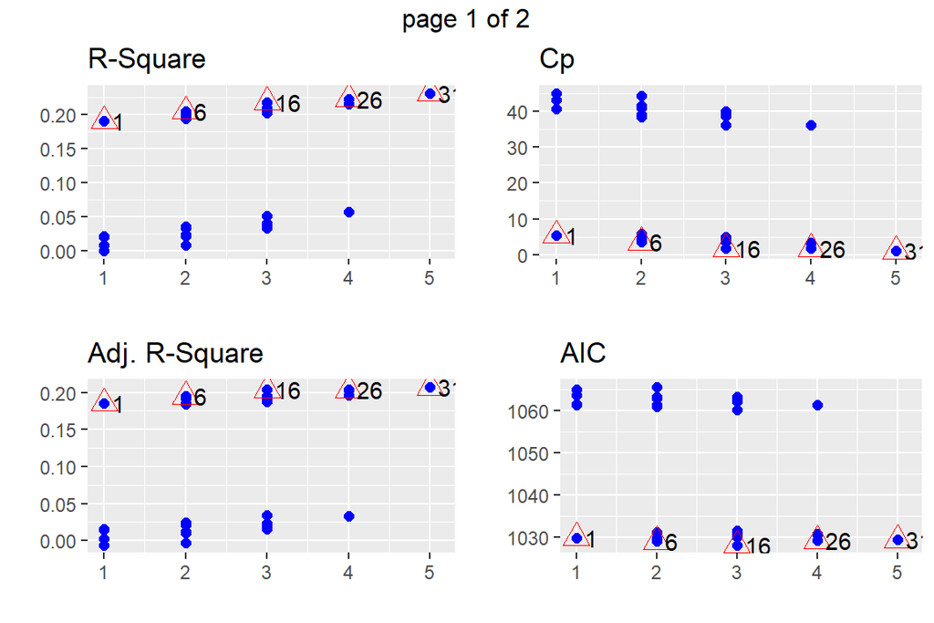

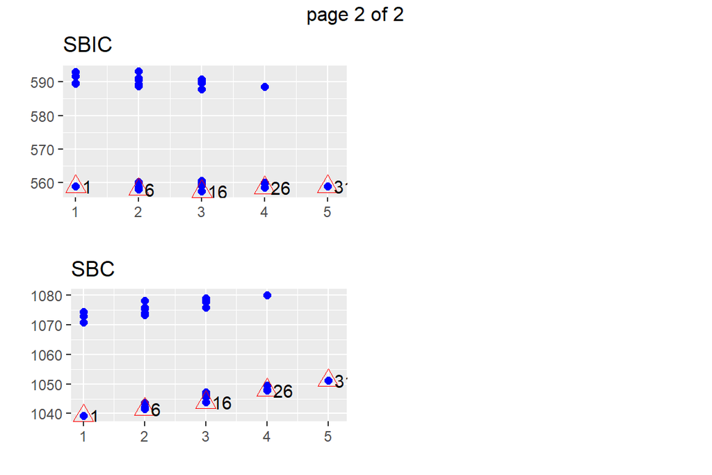

```r
kplot<-ols_step_all_possible(mod1)
plot(kplot)
```

The convention with model stats is usually maximise R-squared and minimise AIC and MSE. But for the best subset of variables, the package has readily made function, which we will try below.

```r
ols_step_best_subset(mod1)
```

```
##          Best Subsets Regression
## ------------------------------------------
## Model Index    Predictors
## ------------------------------------------
##      1         attitude
##      2         attitude stra
##      3         attitude Age stra
##      4         attitude Age deep stra
##      5         attitude Age deep stra surf
## ------------------------------------------
##
##                                                      Subsets Regression Summary
## -------------------------------------------------------------------------------------------------------------------------------------
##                        Adj.        Pred
## Model    R-Square    R-Square    R-Square     C(p)        AIC         SBIC         SBC         MSEP         FPE       HSP       APC
## -------------------------------------------------------------------------------------------------------------------------------------
##   1        0.1906      0.1856      0.1701    6.4442    1029.9875    558.8415    1039.3235    4697.7198    28.6404    0.1736    0.8292
##   2        0.2048      0.1951      0.1785    5.4776    1029.0379    557.9692    1041.4858    4643.4709    28.4772    0.1727    0.8245
##   3        0.2182      0.2037      0.1764    4.6969    1028.2247    557.2987    1043.7847    4593.7993    28.3381    0.1719    0.8204
##   4        0.2228      0.2035      0.1715    5.7310    1029.2363    558.4113    1047.9082    4595.0677    28.5116    0.1730    0.8255
##   5        0.2311      0.2071      0.1677    6.0000    1029.4500    558.8096    1051.2339    4574.4766    28.5487    0.1733    0.8265
## -------------------------------------------------------------------------------------------------------------------------------------
## AIC: Akaike Information Criteria
##  SBIC: Sawa's Bayesian Information Criteria
##  SBC: Schwarz Bayesian Criteria
##  MSEP: Estimated error of prediction, assuming multivariate normality
##  FPE: Final Prediction Error
##  HSP: Hocking's Sp
##  APC: Amemiya Prediction Criteria
```

LOL, more regression summary statistics than i care for! Lets try plotting this so its a bit more intuitive.

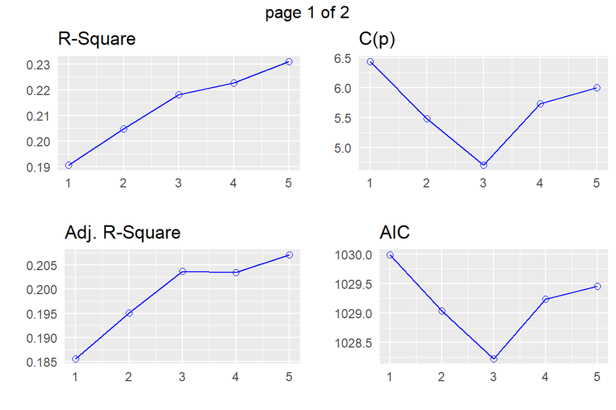

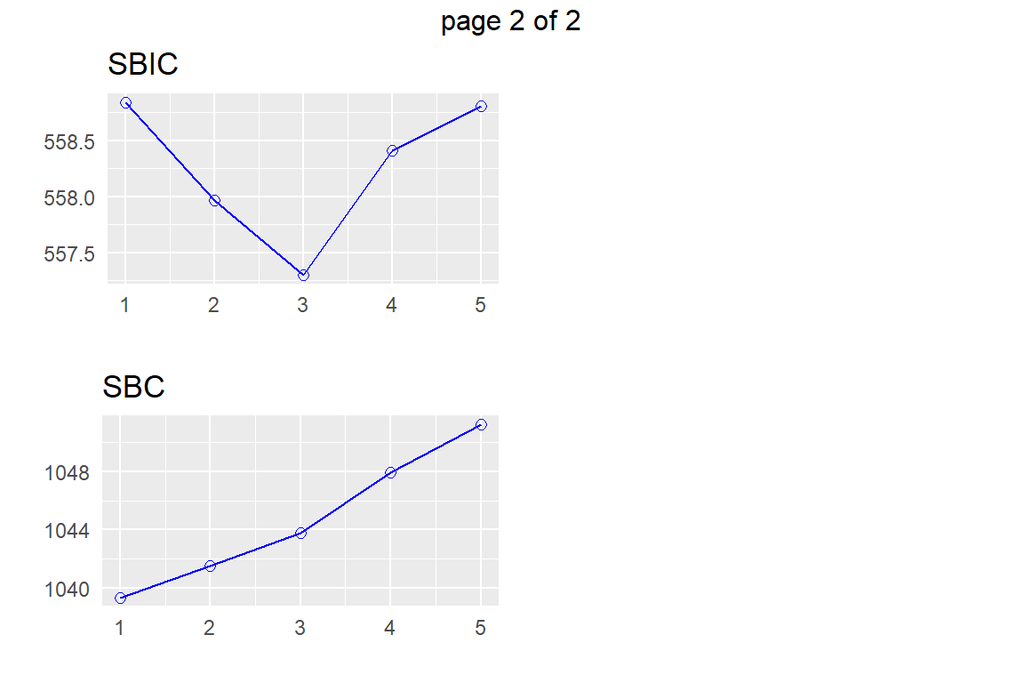

```r
kplot1<-ols_step_best_subset(mod1)
plot(kplot1)
```

##### **Stepwise backward regression** methods

```r
mod2<-lm(formula= Points ~ .,data=student2014)
summary(mod2)
```

```
##
## Call:
## lm(formula = Points ~ ., data = student2014)
##
## Residuals:
##      Min       1Q   Median       3Q      Max
## -17.4506  -3.2479   0.3879   3.5243  11.4820
##
## Coefficients:
##             Estimate Std. Error t value Pr(>|t|)
## (Intercept) 18.30246    5.25723   3.481 0.000644 ***
## genderM     -0.05858    0.92985  -0.063 0.949845
## Age         -0.09607    0.05396  -1.780 0.076929 .
## attitude     3.44300    0.59776   5.760 4.24e-08 ***
## deep        -1.04279    0.78438  -1.329 0.185606
## stra         0.95871    0.55150   1.738 0.084083 .
## surf        -1.10891    0.84467  -1.313 0.191132
## ---
## Signif. codes:  0 '***' 0.001 '**' 0.01 '*' 0.05 '.' 0.1 ' ' 1
##
## Residual standard error: 5.265 on 159 degrees of freedom
## Multiple R-squared:  0.2312, Adjusted R-squared:  0.2021
## F-statistic: 7.967 on 6 and 159 DF,  p-value: 1.599e-07
```

```r
#Notice slightly different function. This is choosing models on AIC.
ols_step_backward_aic(mod2)
```

```
##
##
##                       Backward Elimination Summary
## ----------------------------------------------------------------------
## Variable        AIC         RSS        Sum Sq      R-Sq      Adj. R-Sq
## ----------------------------------------------------------------------
## Full Model    1031.446    4408.344    1325.349    0.23115      0.20214
## gender        1029.450    4408.454    1325.239    0.23113      0.20710
## surf          1029.236    4456.149    1277.544    0.22281      0.20350
## deep          1028.225    4482.762    1250.931    0.21817      0.20369
## ----------------------------------------------------------------------
```

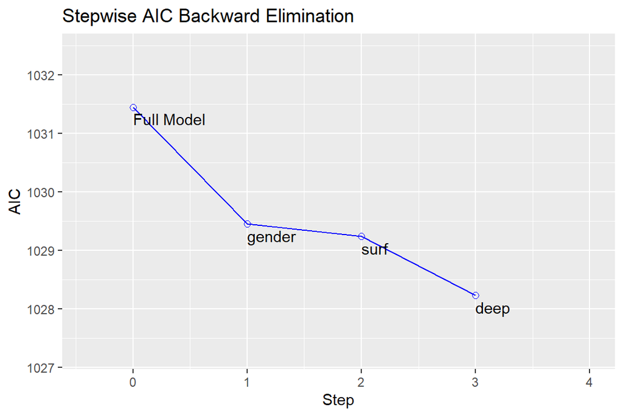

```r
kplot2<-ols_step_backward_aic(mod2)
plot(kplot2)
```

```r
#If we do it based on p value,
ols_step_backward_p(mod2)
```

```
##
##
##                            Elimination Summary
## -------------------------------------------------------------------------
##         Variable                  Adj.
## Step    Removed     R-Square    R-Square     C(p)        AIC        RMSE
## -------------------------------------------------------------------------
##    1    gender        0.2311      0.2071    5.0040    1029.4500    5.2491
## -------------------------------------------------------------------------
```

```r
#Only removes gender from the model, which is slightly different to backward selection based on AIC
```

The results of the step_backward_aic method matches with the best selection method above. I’d be happy to go with that. Hence the final model of choice based on the above two methods is below in final<-lm:

#====================================================================================================================

#### **Task 4 - Model interpretation**

```r
final<-lm(formula= Points ~ attitude+Age+stra,data=student2014)
summary(final)
```

```
##
## Call:
## lm(formula = Points ~ attitude + Age + stra, data = student2014)
##
## Residuals:
##      Min       1Q   Median       3Q      Max
## -18.1149  -3.2003   0.3303   3.4129  10.7599
##
## Coefficients:
##             Estimate Std. Error t value Pr(>|t|)
## (Intercept) 10.89543    2.64834   4.114 6.17e-05 ***
## attitude     3.48077    0.56220   6.191 4.72e-09 ***
## Age         -0.08822    0.05302  -1.664   0.0981 .
## stra         1.00371    0.53434   1.878   0.0621 .
## ---
## Signif. codes:  0 '***' 0.001 '**' 0.01 '*' 0.05 '.' 0.1 ' ' 1
##
## Residual standard error: 5.26 on 162 degrees of freedom
## Multiple R-squared:  0.2182, Adjusted R-squared:  0.2037
## F-statistic: 15.07 on 3 and 162 DF,  p-value: 1.07e-08
```

**Call:** This is the function that we are calling. Our final model that we are going to dissect below

**Residuals:** This tells us how well the model fits to the data. It tells us the distance of points away from the main regression line at 5 different places: Minimum, maximum, median, 1st quartile and 3rd quartile (all in units of distancee, rather than actual value).

**Signif.codes:** These relate to significance levels of p-value. Triple star means most significant, dots and space means less significant.

**Model fit stats** Stuff below the significance levels are about model performance statistics. The main one i look at is R-squared values (how much of the variance in the data did the model explain?). In this case its only around 20% - which is quite underwhelming. The difference between the multiple and adjusted R-squared is when penalty is applied to the number of independent variables included in the model. Ideally, we want R-squared values (particularly adjusted R-squared) value closer to 1, which would mean nearly all variability in data is explained by the model.

#====================================================================================================================

#### **Task 5 - Diagnostics**

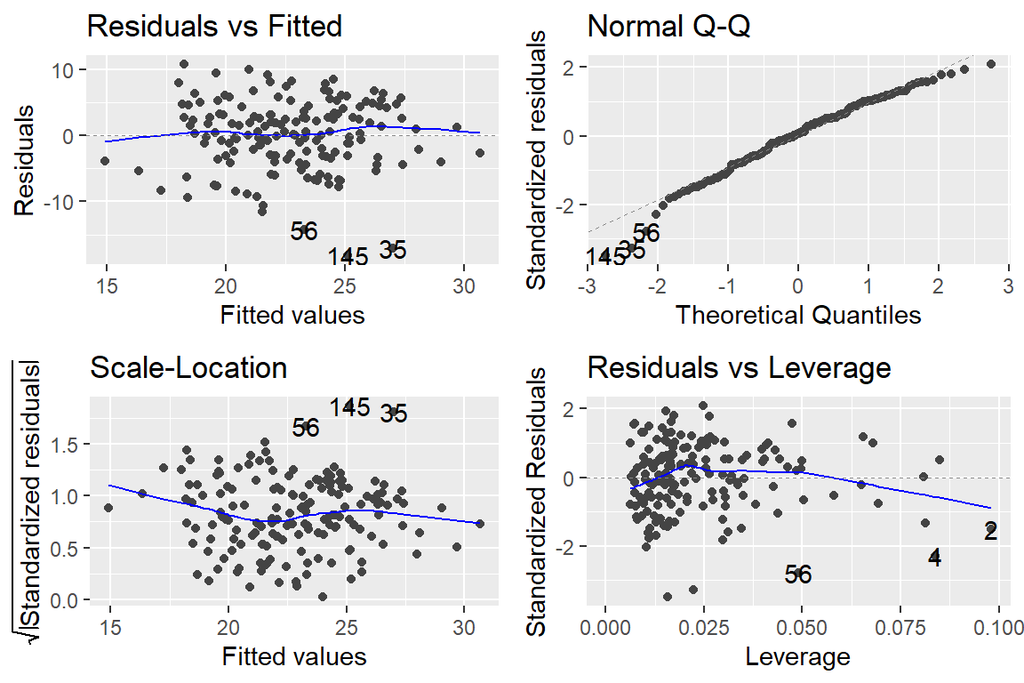

```r
library(ggfortify)
autoplot(final)
```

**Residuals vs Fitted** This shows if the residuals of the model have a normal distribution. If there are abnormal shapes (such as fanning, or curves), that usually indicates that the residuals aren’t normally distributed and therefore the model does not comply with the assumptions of the model (in linear regression this is a must). In this instance, it don’t see any fanning or curving, so that’s fine.

**Normal QQ plot** In this plot, we want to points to be perfectly aligned to the diagonal line, which would indicate a perfect fit. In our case, there are some parts of the data that does large deviation, which means model fit is not very good at the extreme ends. Particular outliers stand out, 56, 145 and 35 are row ids for some special cases in our data set. They do not comply well to the regression line!

**Residuals vs Leverage** This tells us about influence of individual data points (called leverage). Here, data points 4 and 2 (pulling the fitted line at one end) are big influencers (highest leverage). 56 is kind of in the middle, but very much an outlier still (from QQ plot).

#====================================================================================================================

# Week 3 - Logistic Regression

```r
date()
```

```
## [1] "Tue Dec 12 21:48:25 2023"
```

#### **Task 1 - Describe the data briefly**

This is the dataframe saved locally on my computer

```r
library(tidyverse)
unique_students<-read_csv("students_from_math_and_porteguese_classes_and_alc_consumption.csv")
glimpse(unique_students)
```

```
## Rows: 370
## Columns: 44
## $ school             <chr> "GP", "GP", "GP", "GP", "GP", "GP", "GP", "GP", "GP…
## $ sex                <chr> "F", "F", "F", "F", "F", "F", "F", "F", "F", "F", "…
## $ age                <dbl> 15, 15, 15, 15, 15, 15, 15, 15, 15, 15, 15, 15, 15,…
## $ address            <chr> "R", "R", "R", "R", "R", "R", "R", "R", "R", "U", "…
## $ famsize            <chr> "GT3", "GT3", "GT3", "GT3", "GT3", "GT3", "GT3", "L…
## $ Pstatus            <chr> "T", "T", "T", "T", "T", "T", "T", "T", "T", "A", "…
## $ Medu               <dbl> 1, 1, 2, 2, 3, 3, 3, 2, 3, 3, 4, 1, 1, 1, 1, 1, 2, …
## $ Fedu               <dbl> 1, 1, 2, 4, 3, 4, 4, 2, 1, 3, 3, 1, 1, 1, 2, 2, 1, …
## $ Mjob               <chr> "at_home", "other", "at_home", "services", "service…
## $ Fjob               <chr> "other", "other", "other", "health", "services", "h…
## $ reason             <chr> "home", "reputation", "reputation", "course", "repu…
## $ guardian           <chr> "mother", "mother", "mother", "mother", "other", "m…
## $ traveltime         <dbl> 2, 1, 1, 1, 2, 1, 2, 2, 2, 1, 1, 3, 1, 1, 1, 1, 3, …
```

[output cut: 31 more lines]

The above data was created by joining two separate dataframes of students from Maths and Porteguese classes. We merged the dataframes by the common columns in both dataframes, removed duplicate students from both datasets (in case some students did both courses). Then we summarised the alcohol consumption during the weekday (average of Dalc column) from all students. This is alc_use_weekday column. And similarly, alcohol consumption during the weekend (average of Walc column). Inevitably, the average alcohol intake during the weekend was higher because students liked to party more during the weekend. The average alcohol consumption for all students both during the week and weekend is in column named alc_use. Then i went on to create a logical column that stated the alcohol consumption at individual student’s level (if either of Dalc and Walc was above 2 units) under high_use_each_case column. The high_use column is if the global average (alc_use) was above 2 units. Full working of the data wrangling part is here: https://github.com/kbatpurev/IODS-project/blob/master/create_alc.R

#### **Task 2 - Choose 4 variables of interest**

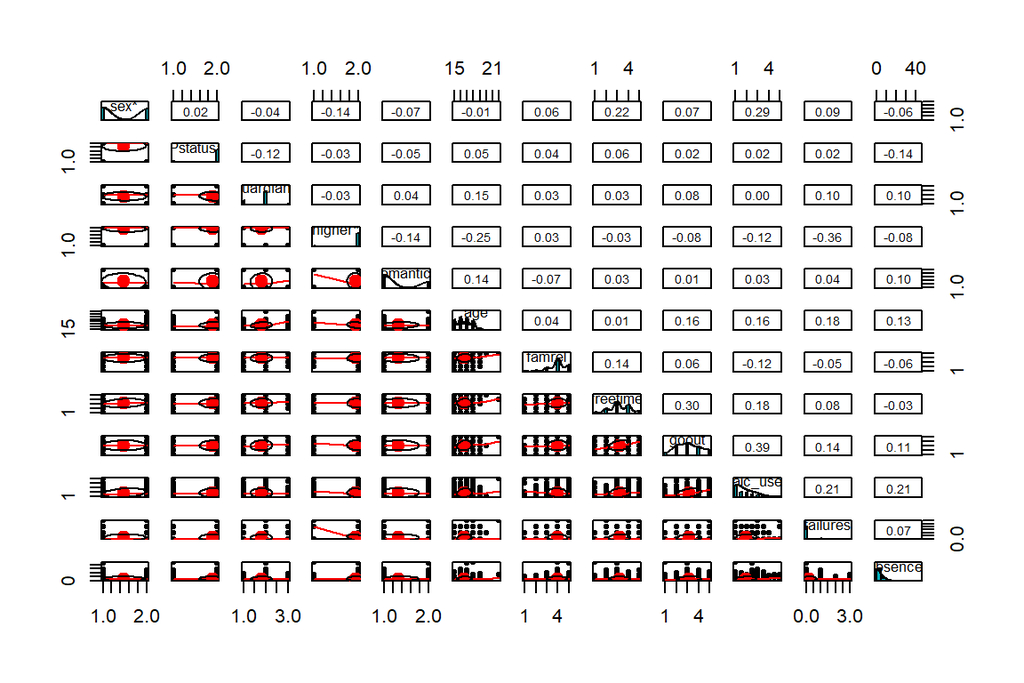

```r
#Source data
alc <- read_csv("https://raw.githubusercontent.com/KimmoVehkalahti/Helsinki-Open-Data-Science/master/datasets/alc.csv", show_col_types=FALSE)
library(ggplot2)
library(GGally)

#These are the possible columns of interest
MyVar <- c("sex","Pstatus","guardian","higher","romantic","age","famrel","freetime","goout","alc_use","failures","absences")
library(psych)
pairs.panels(alc[,MyVar],
             method = "pearson", # correlation method
             hist.col = "#00AFBB",
             density = TRUE,  # show density plots
             )
```

**4 variables of interest** 1. Going out (free time is correlated to this, and therefore i am choosing not to include that to avoid collinearity) and 2. Sex 3. Absences 4. Failures

These are in descending order of Pearson’s correlation coefficient score presented in pairs plot. I thought about removing failures and including age instead, because i thought absences would explain exam failures, but the correlation between these two is only 0.07, which indicates they are not hugely correlated and therefore not imposing collinearity issues further down the line.

#### **Task 3 - Numerically and graphically explore the chosen variables**

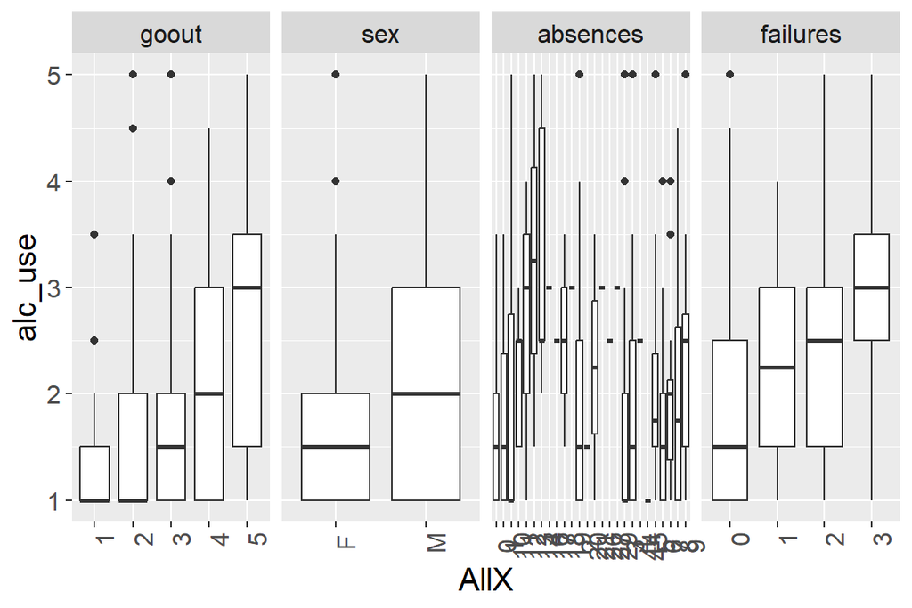

```r
library(tidyverse)
#Here i choose subset of social variables that interest me
cols_interest<-dplyr::select(alc,c("goout","sex","absences","failures","alc_use"))

#Further subset of variables that i am going to plot
GatherTheseCols <- c("goout","sex","absences","failures")
interest_long<- gather(data = cols_interest,
                  key = "ID",
                  value = "AllX",
                  GatherTheseCols,
                  factor_key = TRUE)
interest_plot<-ggplot(data = interest_long, aes(y=alc_use,x=AllX)) +
      geom_boxplot()+
      theme(text = element_text(size=15))+facet_grid(.~ID,scales="free_x")+
      theme(axis.text.x = element_text(angle=90))
interest_plot
```

Absences and alcohol intake have potentially non-linear relationship! The rest are quite predictable. Males’ intake of alcohol is higher than females, going out more is highly correlated with high alcohol use. The number of failures in class in the past is associated with higher alcohol intake. Interesting correlation/causation question there…Does past failures cause self-confidence issues relating to alcohol abuse or higher alcohol intake is likely to make you fall behind school and therefore becoming the cause of failures in classes? Further investigation needed.

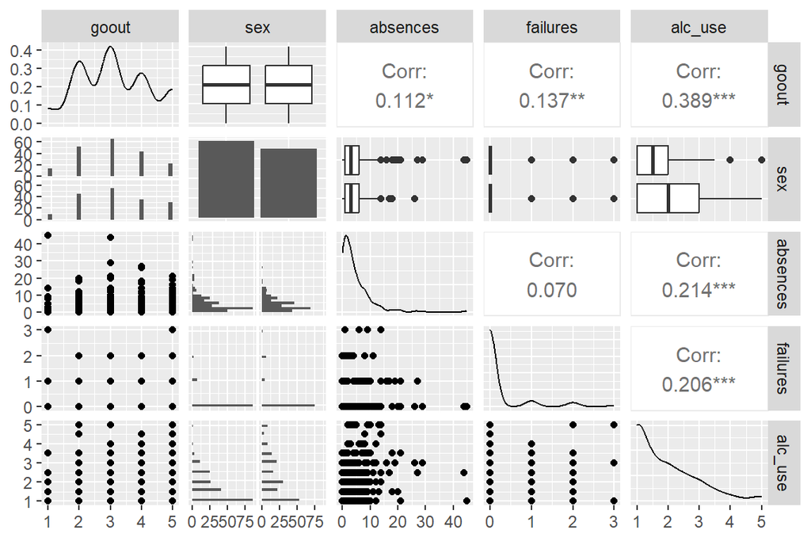

```r
library(GGally)
library(finalfit)
cols_interest%>%
  remove_labels() %>%
  ggpairs()
```

This suggests that absences have very little impact on failures. Interesting…A bit further investigation to explore what the impact of going out has on failures and alcohol consumption.

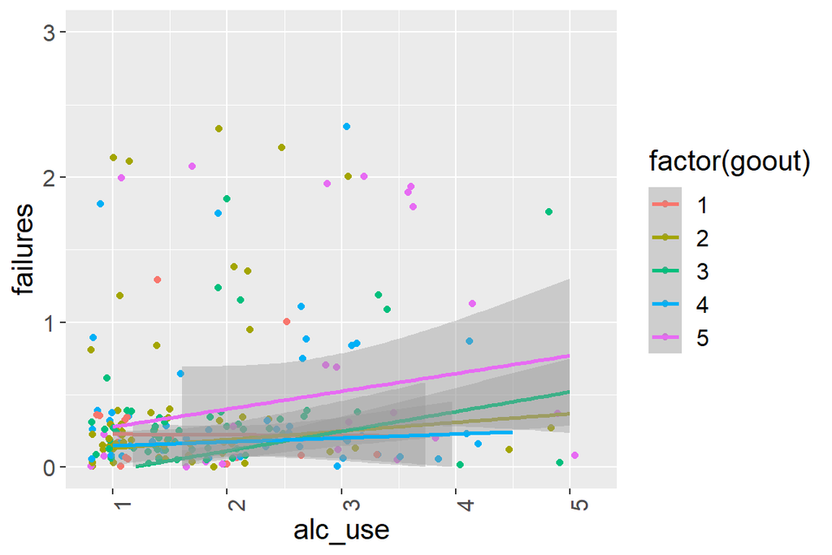

```r
goout_failures<-ggplot(data = cols_interest, aes(y=failures,x=alc_use,colour=factor(goout))) +
      geom_jitter()+geom_smooth(method="lm")+
  scale_fill_viridis_c()+
      theme(text = element_text(size=15))+
      theme(axis.text.x = element_text(angle=90))+
  ylim(c(0,3))
goout_failures
```

From this we can confirm that high alcohol use is related to higher number of past failures. And the more social drinking (going out a lot) is also associated with exam failures. Slopes are slightly different for “go out” factor, suggesting that there maybe some non -linear relationships going on.

#### **Task 4 - Logistic regression**

```r
logdata<-dplyr::select(alc,c("goout","sex","absences","failures","alc_use","high_use"))
str(logdata)
```

```
## tibble [370 × 6] (S3: tbl_df/tbl/data.frame)
##  $ goout   : num [1:370] 4 3 2 2 2 2 4 4 2 1 ...
##  $ sex     : chr [1:370] "F" "F" "F" "F" ...
##  $ absences: num [1:370] 5 3 8 1 2 8 0 4 0 0 ...
##  $ failures: num [1:370] 0 0 2 0 0 0 0 0 0 0 ...
##  $ alc_use : num [1:370] 1 1 2.5 1 1.5 1.5 1 1 1 1 ...
##  $ high_use: logi [1:370] FALSE FALSE TRUE FALSE FALSE FALSE ...
```

```r
#Sex is a character here. We have to turn this into a factor for GLM to treat it properly. While we are at it, do the same for logical var high_use as this will be our response variable in the binomial model
logdata$sex<-as.factor(logdata$sex)
logdata$high_use<-as.factor(logdata$high_use)

bin_full<- glm(high_use ~ failures + absences + sex + goout, data = logdata, family = "binomial")
summary(bin_full)
```

```
##
## Call:
## glm(formula = high_use ~ failures + absences + sex + goout, family = "binomial",
##     data = logdata)
##
## Coefficients:
##             Estimate Std. Error z value Pr(>|z|)
## (Intercept) -4.14389    0.47881  -8.654  < 2e-16 ***
## failures     0.48932    0.23073   2.121 0.033938 *
## absences     0.08246    0.02266   3.639 0.000274 ***
## sexM         0.97989    0.26156   3.746 0.000179 ***
## goout        0.69801    0.12093   5.772 7.83e-09 ***
## ---
## Signif. codes:  0 '***' 0.001 '**' 0.01 '*' 0.05 '.' 0.1 ' ' 1
##
## (Dispersion parameter for binomial family taken to be 1)
##
##     Null deviance: 452.04  on 369  degrees of freedom
## Residual deviance: 369.50  on 365  degrees of freedom
## AIC: 379.5
##
## Number of Fisher Scoring iterations: 4
```

This suggests that all predictors (sex, failures, going out and absences) are significant in the model at 95% level or above. Students’ sex, social habits (going out) and failures have relatively high impact on determining whether student belong to high alcohol intake classification (log(odds(high_use))). The odds ratio for these variables are 2.66, 2 and 1.63 respectively. We get this by exp() of corresponding estimate values. Surprisingly, absences have the least impact on the likelihood of student’s likelihood of being in high alcohol group. Alternatively, we just get the tidy() function like below.

```r
library(broom)
bin_full %>%
  tidy(conf.int = TRUE, exp = TRUE)
```

```
## # A tibble: 5 × 7
##   term        estimate std.error statistic  p.value conf.low conf.high
##   <chr>          <dbl>     <dbl>     <dbl>    <dbl>    <dbl>     <dbl>
## 1 (Intercept)   0.0159    0.479      -8.65 4.95e-18  0.00595    0.0391
## 2 failures      1.63      0.231       2.12 3.39e- 2  1.04       2.59
## 3 absences      1.09      0.0227      3.64 2.74e- 4  1.04       1.14
## 4 sexM          2.66      0.262       3.75 1.79e- 4  1.61       4.49
## 5 goout         2.01      0.121       5.77 7.83e- 9  1.59       2.56
```

Here we have the Odds ration under estimate column at 95% CI. Confidence intervals are in column 6 and 7, you will have to scroll back.

```r
bin_full%>%glance()
```

```
## # A tibble: 1 × 8
##   null.deviance df.null logLik   AIC   BIC deviance df.residual  nobs
##           <dbl>   <int>  <dbl> <dbl> <dbl>    <dbl>       <int> <int>
## 1          452.     369  -185.  379.  399.     369.         365   370
```

Hmmm the df. residuals is high, so maybe further investigation is necessary, I am going the old fashioned way here.

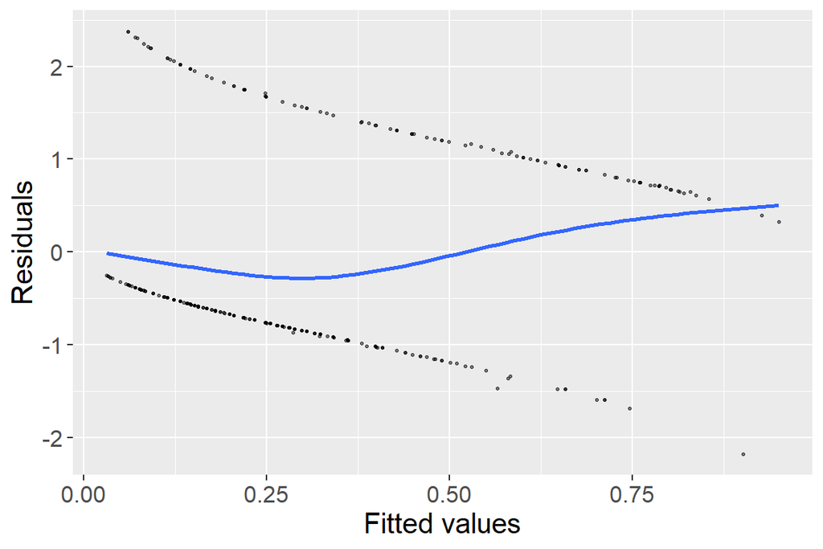

```r
r_binfull<-rstandard(bin_full)
f_binfull<-fitted(bin_full)


ggplot(data = bin_full, aes(x = f_binfull, y = r_binfull)) +
    geom_point( size = 0.5, alpha = 0.5) +
    geom_smooth(method = "gam", se = FALSE) +
    labs(x = "Fitted values", y = "Residuals") +
    theme(text = element_text(size = 15))
```

This is not looking very good. The fact that there is some curvature on the shape of the residuals suggests to me the model fitting is less than perfect. Lets test this on a variable that wasn’t used in the model (this is a method proposed by Zuur et al., 2016.)

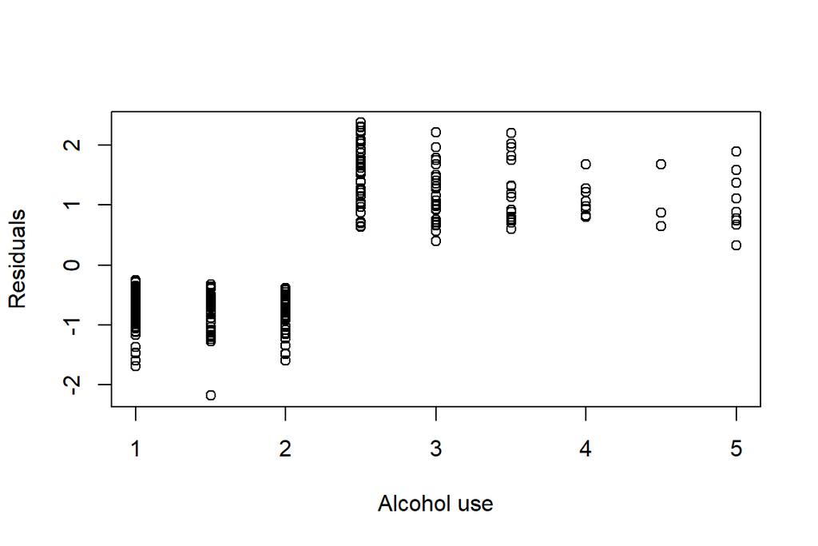

```r
plot(x = logdata$alc_use,
     y = r_binfull,
     xlab = "Alcohol use",
     ylab = "Residuals")
```

Ok suspicion confirmed. Model is clearly over dispersed at higher values of alcohol use. So further fine tuning of this model is necessary before it being fit for use. For the sake of this exercise however, i am going to continue with the bin_full model for now.

#### **Task 5 - Predict function**

The predict() function uses the fitted model to create probability values between 0 and 1. Its a very convenient way of using a logistic regression model output, as odds ratio and likelihood does my head in!

```r
prob_high_alc<- predict(bin_full, type = "response")
logdata<- mutate(logdata, prob = prob_high_alc)
logdata<-mutate(logdata,pred=prob>0.5)
```

##### Tabulating

```r
table(high_use=logdata$high_use,prediction=logdata$pred)
```

```
##         prediction
## high_use FALSE TRUE
##    FALSE   243   16
##    TRUE     61   50
```

A bit messy! Low false positives, but quite high false negatives! Error rate is usually calculated by (false positive+false negatives)/(Positive+negative) and accuracy is the inverse of this. Error is (61+16)/(243+16+61+50)=0.20 Accuracy is 1-error=0.8

To me there is a bit of a mismatch between the accuracy and model fitness. I’d say that model was not fit very well (residuals not completely random). there maybe some overfitting involved, which will push the accuracy metrics up.

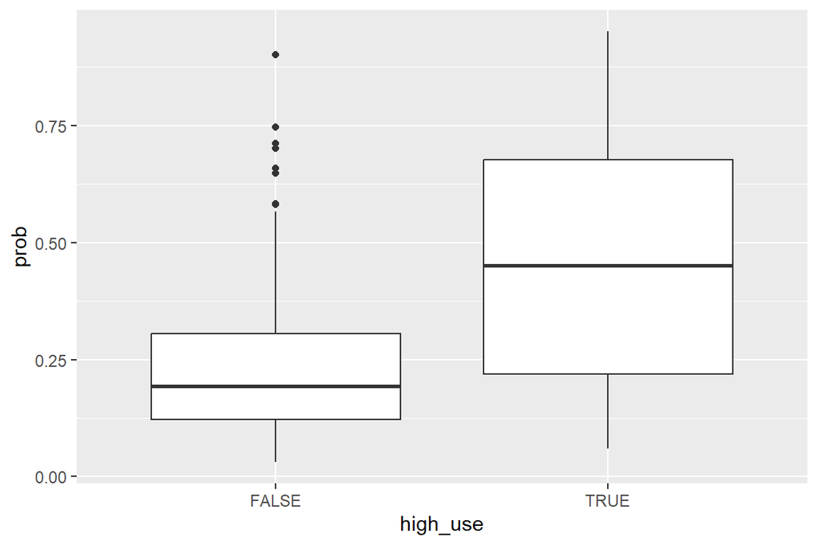

```r
g <- ggplot(logdata, aes(x = high_use, y = prob))+geom_boxplot()
g
```

Boxplot makes sense to me. Though there is a grey area where the TRUE and FALSE overlap a fair bit around probability of 0.2 and 0.4. Could go either way…that suggests a fair bit of misclassification at that end.

#### **Task 6 - Bonus**

To perform cross validation we need a loss function first, the use the boot library cv.glm function which gives us the average number of wrong predictions.

```r
loss_func <- function(class, prob) {
  n_wrong <- abs(class - prob) > 0.5
  mean(n_wrong)
}
library(boot)
cv <- cv.glm(data = logdata, cost = loss_func, glmfit = bin_full, K = 10)
cv$delta[1]
```

```
## [1] 0.2162162
```

```r
#0.21 which seems to correspond to the error that we calculated above by hand. And yes its better than the model given in example exercise, which didn't have going out as a predictor.
```

#### **Task 6 - Extra bonus**

```r
library(finalfit)
dependent <- "high_use"
explanatory <- c("sex","Pstatus","guardian","higher","romantic","age","famrel","freetime","goout","failures","absences")
explanatory_1<-c("sex","failures","absences","goout")

alc %>%
  finalfit(dependent, explanatory, explanatory_1,
           keep_models = TRUE, metrics = TRUE)
```

```
## [[1]]
##  Dependent: high_use                FALSE       TRUE
##                  sex         F 154 (79.0)  41 (21.0)
##                              M 105 (60.0)  70 (40.0)
##              Pstatus         A  26 (68.4)  12 (31.6)
##                              T 233 (70.2)  99 (29.8)
##             guardian    father  59 (67.0)  29 (33.0)
##                         mother 191 (71.8)  75 (28.2)
##                          other   9 (56.2)   7 (43.8)
##               higher        no   7 (43.8)   9 (56.2)
##                            yes 252 (71.2) 102 (28.8)
##             romantic        no 173 (68.9)  78 (31.1)
##                            yes  86 (72.3)  33 (27.7)
##                  age Mean (SD) 16.5 (1.2) 16.8 (1.2)
##               famrel Mean (SD)  4.0 (0.9)  3.8 (0.9)
##             freetime Mean (SD)  3.1 (1.0)  3.5 (0.9)
##                goout Mean (SD)  2.9 (1.0)  3.7 (1.1)
##             failures         0 238 (73.2)  87 (26.8)
##                              1  12 (50.0)  12 (50.0)
##                              2   8 (47.1)   9 (52.9)
##                              3   1 (25.0)   3 (75.0)
##             absences Mean (SD)  3.7 (4.5)  6.4 (7.1)
##        Coefficient (univariable) Coefficient (multivariable full)
##                                -                                -
##     0.19 (0.10 to 0.28, p<0.001)     0.17 (0.08 to 0.25, p<0.001)
##                                -                                -
##   -0.02 (-0.17 to 0.14, p=0.823)   -0.01 (-0.15 to 0.13, p=0.902)
##                                -                                -
##   -0.05 (-0.16 to 0.06, p=0.399)   -0.09 (-0.19 to 0.01, p=0.094)
##    0.11 (-0.14 to 0.35, p=0.387)    0.01 (-0.21 to 0.24, p=0.909)
##                                -                                -
##  -0.27 (-0.50 to -0.05, p=0.019)   -0.07 (-0.30 to 0.17, p=0.569)
##                                -                                -
##   -0.03 (-0.13 to 0.07, p=0.513)   -0.07 (-0.16 to 0.03, p=0.154)
##     0.04 (0.00 to 0.08, p=0.042)    0.01 (-0.03 to 0.05, p=0.693)
##  -0.06 (-0.11 to -0.01, p=0.019)  -0.07 (-0.12 to -0.03, p=0.002)
##     0.08 (0.03 to 0.12, p=0.002)    0.02 (-0.02 to 0.07, p=0.351)
##     0.14 (0.11 to 0.18, p<0.001)     0.13 (0.09 to 0.17, p<0.001)
##                                -                                -
##     0.23 (0.04 to 0.42, p=0.016)    0.15 (-0.02 to 0.33, p=0.087)
```

[output cut: 16 more lines]

```
##                              -
##                              -
##   0.13 (0.09 to 0.16, p<0.001)
##                              -
##   0.19 (0.01 to 0.36, p=0.035)
##  0.15 (-0.05 to 0.35, p=0.146)
##  0.27 (-0.14 to 0.67, p=0.200)
##   0.02 (0.01 to 0.02, p<0.001)
##
## [[2]]
## [[2]][[1]]
## [1] "Number in dataframe = 370, Number in model = 370, Missing = 0, Log-likelihood = -183.54, AIC = 399.1, R-squared = 0.25, Adjusted R-squared = 0.22"
##
## [[2]][[2]]
## [1] "Number in dataframe = 370, Number in model = 370, Missing = 0, Log-likelihood = -191.38, AIC = 398.8, R-squared = 0.22, Adjusted R-squared = 0.2"
```

# Week 4 - Clustering

```
## [1] "Tue Dec 12 21:48:36 2023"
```

```
## here() starts at C:/LocalData/batkhor/Coursework/IODS_23/IODS-project
```

#### **Task 1 - Load Boston data**

```
## 'data.frame':    506 obs. of  14 variables:
##  $ crim   : num  0.00632 0.02731 0.02729 0.03237 0.06905 ...
##  $ zn     : num  18 0 0 0 0 0 12.5 12.5 12.5 12.5 ...
##  $ indus  : num  2.31 7.07 7.07 2.18 2.18 2.18 7.87 7.87 7.87 7.87 ...
##  $ chas   : int  0 0 0 0 0 0 0 0 0 0 ...
##  $ nox    : num  0.538 0.469 0.469 0.458 0.458 0.458 0.524 0.524 0.524 0.524 ...
##  $ rm     : num  6.58 6.42 7.18 7 7.15 ...
##  $ age    : num  65.2 78.9 61.1 45.8 54.2 58.7 66.6 96.1 100 85.9 ...
##  $ dis    : num  4.09 4.97 4.97 6.06 6.06 ...
##  $ rad    : int  1 2 2 3 3 3 5 5 5 5 ...
##  $ tax    : num  296 242 242 222 222 222 311 311 311 311 ...
##  $ ptratio: num  15.3 17.8 17.8 18.7 18.7 18.7 15.2 15.2 15.2 15.2 ...
##  $ black  : num  397 397 393 395 397 ...
##  $ lstat  : num  4.98 9.14 4.03 2.94 5.33 ...
##  $ medv   : num  24 21.6 34.7 33.4 36.2 28.7 22.9 27.1 16.5 18.9 ...
```

```
## [1] 506  14
```

Boston dataset is one of the popular publically available datasets in R. Its a sociology study dataset that desribes a broad range of demographic, housing infrastructure and environmental variables related to the city of Boston, MA. The dataset has 506 rows and 14 columns. A more detailed description of the dataset can be found here https://stat.ethz.ch/R-manual/R-devel/library/MASS/html/Boston.html.

#### **Task 2 - Graphical overview of Boston data**

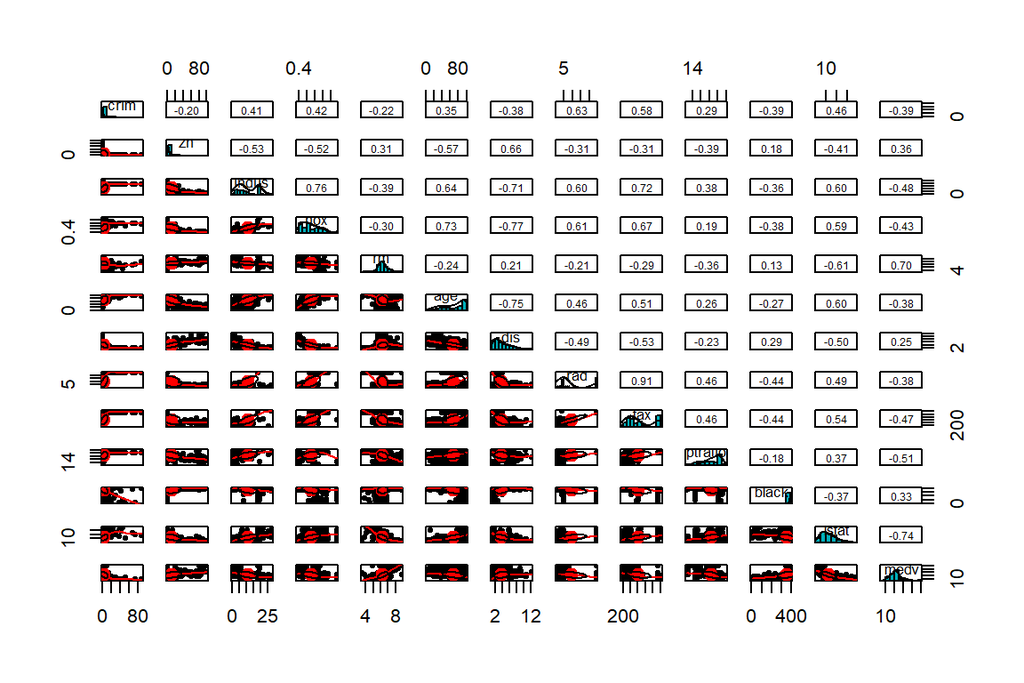

```r
library(psych)
Boston<-dplyr::select(Boston,-chas) #I removed this variable because its a dummy variable and we only want to see the relationships between relevant stuff.
pairs.panels(Boston,
             method = "pearson", # correlation method
             hist.col = "#00AFBB",
             density = TRUE,  # show density plots
             )
```

```r
#I prefer pairs.panel function over corrplot in the exercise because i get precise correlation values rather than coloured circles...

#cor_matrix <- cor(Boston)
#corrplot(cor_matrix, method="circle")
```

##### Distributions of variables

**Bi-modal distribution**: accessibility to radial highways (rad), value of property-tax rate per $10,000 (tax) and proportion of non-retail business acres per town (indus). These variables have two peaks i.e., they have high proportion of values at both low and high scales.

##### Relationship between variables

The most significant **positively** correlated variables in the descending order of Pearson’s correlation coefficient are:

1. *accessibility to radial highways* (rad) vs.*full-value property-tax rate per $10,000* (tax) = 0.91 This indicates that the location of properties in relation to highways determine the value of the property - higher value would mean higher tax rate.
2. *proportion of non-retail business acres per town* (indus) vs. *nitrogen oxides concentration (parts per 10 million)* (nox) = 0.76 This suggests that pollution levels in industrial zones of Boston are high.
3. *nitrogen oxides concentration (parts per 10 million)* (nox) vs. *proportion of owner-occupied units built prior to 1940* (age) = 0.73 This suggests that older residential areas tend to have higher air pollution levels, which maybe due to industrial era housing being associated with industrial zones (workers living close to factories). It’s interesting because in many non-industrial cities around the world, this correlation might be negative because older residential areas tend to be close to city centres where traffic rate is often low and restricted (due to high parking rates). But I guess Boston being an old industrial hub of the US, this association makes sense.
4. *proportion of non-retail business acres per town* (indus) vs. *full-value property-tax rate per $10,000* (tax) = 0.72. This indicates that industrial real estates are high value in Boston.

These all make sense. Perhaps the most striking inverse correlation (from what i would have guessed) was between property value tax and low socio-economic status being positively correlated whilst property tax value and the value of owner occupied homes being negatively correlated. This suggests that poorer people pay high property tax than people who own high value homes! I am not 100% convinced that my interpretation is correct, but the only way it makes sense is that somehow there a taxation mechanism that penalises higher mortgage rate (lower social status people still paying off high debt) whilst if you have paid off your mortgage (higher income/old money people) then property tax is less…? I am still not sure.

#### **Task 3 - Data preparation**

##### Scaling the data

```r
scaled_data<-as.data.frame(scale(Boston,center=TRUE, scale=TRUE))
#Center and scale functions are TRUE by default, but typed here i typed it in to remind myself what i exactly did later on.

glimpse(scaled_data)
```

```
## Rows: 506
## Columns: 13
## $ crim    <dbl> -0.4193669, -0.4169267, -0.4169290, -0.4163384, -0.4120741, -0…
## $ zn      <dbl> 0.28454827, -0.48724019, -0.48724019, -0.48724019, -0.48724019…
## $ indus   <dbl> -1.2866362, -0.5927944, -0.5927944, -1.3055857, -1.3055857, -1…
## $ nox     <dbl> -0.1440749, -0.7395304, -0.7395304, -0.8344581, -0.8344581, -0…
## $ rm      <dbl> 0.4132629, 0.1940824, 1.2814456, 1.0152978, 1.2273620, 0.20689…
## $ age     <dbl> -0.11989477, 0.36680343, -0.26554897, -0.80908783, -0.51067434…
## $ dis     <dbl> 0.1400749840, 0.5566090496, 0.5566090496, 1.0766711351, 1.0766…
## $ rad     <dbl> -0.9818712, -0.8670245, -0.8670245, -0.7521778, -0.7521778, -0…
## $ tax     <dbl> -0.6659492, -0.9863534, -0.9863534, -1.1050216, -1.1050216, -1…
## $ ptratio <dbl> -1.4575580, -0.3027945, -0.3027945, 0.1129203, 0.1129203, 0.11…
## $ black   <dbl> 0.4406159, 0.4406159, 0.3960351, 0.4157514, 0.4406159, 0.41016…
## $ lstat   <dbl> -1.07449897, -0.49195252, -1.20753241, -1.36017078, -1.0254866…
## $ medv    <dbl> 0.15952779, -0.10142392, 1.32293748, 1.18158864, 1.48603229, 0…
```

Scaling changes the values to what i describe as gibberish numbers because we have taken the mean off everything and divided by the spread (standard deviation). But its a useful thing to do when we are interested in exploring the underlying clusters and relationships (fitting models).

##### Making factors

We need quantiles first to choose the factor bins. Then create a new crime variable that is a factor, and rejoin it to the dataframe.

```r
scaled_data$crim<-as.numeric(scaled_data$crim)
factor.bins <- quantile(scaled_data$crim)
factor.bins
```

```
##           0%          25%          50%          75%         100%
## -0.419366929 -0.410563278 -0.390280295  0.007389247  9.924109610
```

```r
crime <- cut(scaled_data$crim, breaks = factor.bins, include.lowest = TRUE)
glimpse(crime)
```

```
##  Factor w/ 4 levels "[-0.419,-0.411]",..: 1 1 1 1 1 1 2 2 2 2 ...
```

```r
scaled_data<-dplyr::select(scaled_data,-crim)
scaled_data_new<-cbind(scaled_data,crime)
glimpse(scaled_data_new)
```

```
## Rows: 506
## Columns: 13
## $ zn      <dbl> 0.28454827, -0.48724019, -0.48724019, -0.48724019, -0.48724019…
## $ indus   <dbl> -1.2866362, -0.5927944, -0.5927944, -1.3055857, -1.3055857, -1…
## $ nox     <dbl> -0.1440749, -0.7395304, -0.7395304, -0.8344581, -0.8344581, -0…
## $ rm      <dbl> 0.4132629, 0.1940824, 1.2814456, 1.0152978, 1.2273620, 0.20689…
## $ age     <dbl> -0.11989477, 0.36680343, -0.26554897, -0.80908783, -0.51067434…
## $ dis     <dbl> 0.1400749840, 0.5566090496, 0.5566090496, 1.0766711351, 1.0766…
## $ rad     <dbl> -0.9818712, -0.8670245, -0.8670245, -0.7521778, -0.7521778, -0…
## $ tax     <dbl> -0.6659492, -0.9863534, -0.9863534, -1.1050216, -1.1050216, -1…
## $ ptratio <dbl> -1.4575580, -0.3027945, -0.3027945, 0.1129203, 0.1129203, 0.11…
## $ black   <dbl> 0.4406159, 0.4406159, 0.3960351, 0.4157514, 0.4406159, 0.41016…
## $ lstat   <dbl> -1.07449897, -0.49195252, -1.20753241, -1.36017078, -1.0254866…
## $ medv    <dbl> 0.15952779, -0.10142392, 1.32293748, 1.18158864, 1.48603229, 0…
## $ crime   <fct> "[-0.419,-0.411]", "[-0.419,-0.411]", "[-0.419,-0.411]", "[-0.…
```

##### Split the data into training and test sets

The code below sets up an index string called s_80, which randomly samples rows from the 506 rows of data in scaled_data_new dataframe, then uses the index object to split the dataframe into 80/20 training and test set.

```r
s_80 <- sample(506,  size = 506* 0.8)
train=scaled_data_new[s_80,]
test=scaled_data_new[-s_80,]
```

#### **Task 4 - Linear discriminant analysis**

```r
lda.train.fit <- lda(crime~., data = train)
lda.train.fit
```

```
## Call:
## lda(crime ~ ., data = train)
##
## Prior probabilities of groups:
## [-0.419,-0.411]  (-0.411,-0.39] (-0.39,0.00739]  (0.00739,9.92]
##       0.2574257       0.2252475       0.2599010       0.2574257
##
## Group means:
##                          zn      indus        nox         rm        age
## [-0.419,-0.411]  0.97759122 -0.9048438 -0.8852659  0.4494737 -0.8910354
## (-0.411,-0.39]  -0.08980211 -0.1952081 -0.5216993 -0.1930260 -0.3087651
## (-0.39,0.00739] -0.37943482  0.1653368  0.3276870  0.1776540  0.4293282
## (0.00739,9.92]  -0.48724019  1.0149946  1.0314021 -0.4302181  0.8088216
##                        dis        rad        tax     ptratio      black
## [-0.419,-0.411]  0.8729951 -0.6837115 -0.7386335 -0.46046413  0.3812478
## (-0.411,-0.39]   0.3073199 -0.5628700 -0.4535852 -0.07488734  0.3031107
## (-0.39,0.00739] -0.3577274 -0.4087315 -0.3082493 -0.29091693  0.0803119
## (0.00739,9.92]  -0.8588695  1.6596029  1.5294129  0.80577843 -0.7878802
##                       lstat        medv
## [-0.419,-0.411] -0.77179403  0.53610954
## (-0.411,-0.39]  -0.06918471 -0.05207728
## (-0.39,0.00739] -0.02011391  0.21409983
## (0.00739,9.92]   0.90930166 -0.69787002
##
## Coefficients of linear discriminants:
##                 LD1         LD2        LD3
## zn       0.09045728  0.78182081 -0.8650857
## indus    0.02660228 -0.17597255  0.3968690
## nox      0.22999665 -0.76141806 -1.3446609
## rm      -0.12374426 -0.11112200 -0.2002430
## age      0.30093325 -0.38298969 -0.2559230
## dis     -0.03301179 -0.34871246  0.1285612
## rad      3.41328136  0.98335392 -0.1582035
## tax      0.03922115 -0.13918822  0.5894732
## ptratio  0.12382111  0.05939848 -0.2646380
## black   -0.13773664  0.01485339  0.1325471
## lstat    0.15341251 -0.20190860  0.3911035
## medv     0.15198584 -0.35457431 -0.1794481
##
## Proportion of trace:
##    LD1    LD2    LD3
## 0.9533 0.0358 0.0109
```

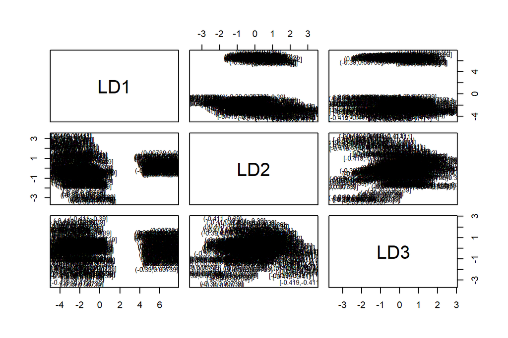

```r
plot(lda.train.fit) #sames as adding extra argument dimen = 3
```

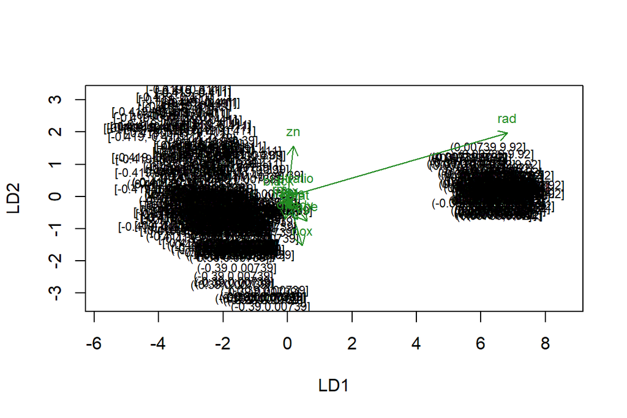

```r
#Create LDA arrow
lda.arrows <- function(x, myscale = 2, arrow_heads = 0.1, color = "forestgreen", tex = 0.75, choices = c(1,2)){
  heads <- coef(x)
  graphics::arrows(x0 = 0, y0 = 0,
         x1 = myscale * heads[,choices[1]],
         y1 = myscale * heads[,choices[2]], col=color, length = arrow_heads)
  text(myscale * heads[,choices], labels = row.names(heads),
       cex = tex, col=color, pos=3)
}

#Turn factor to numeric for plotting purposes
classes <- as.numeric(train$crime)
plot(lda.train.fit,dimen = 2)
lda.arrows(lda.train.fit, myscale = 2)
```

There is clearly two, possibly more clusters from the image above. It seems the main discriminant variable is rad or accessibility to radial highways. The other two influential variables that may help determine the clustering are large residential plots (zn = proportion of residential land zoned for lots over 25,000 sq.ft.) and air pollution levels (nox = nitrogen oxides concentration (parts per 10 million)).

#### **Task 5 - Predict classes**

```r
#Lets reload from source again as we need the original scaled dataset with quantile bins to translate them into low, medium and high categories.
boston_1 <- read.table("https://raw.githubusercontent.com/KimmoVehkalahti/Helsinki-Open-Data-Science/master/datasets/boston_scaled.txt",
                            sep=",", header = T)
boston_1$crime <- factor(boston_1$crime, levels = c("low", "med_low", "med_high", "high"))


s_80 <- sample(506,  size = 506* 0.8)
train=boston_1[s_80,]
test=boston_1[-s_80,]

lda.train.fit <- lda(crime~., data = train)
lda.train.fit
```

```
## Call:
## lda(crime ~ ., data = train)
##
## Prior probabilities of groups:
##       low   med_low  med_high      high
## 0.2326733 0.2673267 0.2400990 0.2599010
##
## Group means:
##                   zn      indus        chas        nox          rm        age
## low       1.06226654 -0.9185949 -0.23044502 -0.9079123  0.46528726 -0.9006981
## med_low  -0.09102369 -0.3037611 -0.05360128 -0.5768508 -0.12434349 -0.3233436
## med_high -0.37054365  0.1739601  0.21473488  0.3633034  0.01093796  0.4296138
## high     -0.48724019  1.0170492 -0.08484810  1.0729721 -0.42816261  0.8114125
##                 dis        rad        tax     ptratio      black       lstat
## low       0.9292634 -0.6874238 -0.7517943 -0.41286557  0.3849406 -0.79699091
## med_low   0.3664814 -0.5426889 -0.4719596 -0.05131268  0.3134861 -0.13997145
## med_high -0.3602470 -0.4265815 -0.3236464 -0.26517540  0.1116942  0.04539287
## high     -0.8539288  1.6388211  1.5145512  0.78158339 -0.7725145  0.86805603
##                 medv
## low       0.55454112
## med_low  -0.02007786
## med_high  0.11749304
## high     -0.67251465
##
## Coefficients of linear discriminants:
##                 LD1         LD2         LD3
## zn       0.08937069  0.82603494 -0.96123850
## indus    0.06229731 -0.19503184  0.13223508
## chas    -0.01897575 -0.15800504  0.04056351
## nox      0.45731621 -0.60005338 -1.42420500
## rm       0.04210764  0.01938335 -0.12260729
## age      0.21707387 -0.31576572 -0.22026434
## dis     -0.07426729 -0.27533799  0.12129961
## rad      3.43915092  0.92196170 -0.05342757
## tax     -0.06563156 -0.09161690  0.75907391
## ptratio  0.14844798  0.09585932 -0.31443113
## black   -0.09150895  0.01028222  0.12724835
## lstat    0.18540495 -0.16786332  0.32017630
## medv     0.11529944 -0.29575666 -0.27229966
##
## Proportion of trace:
##    LD1    LD2    LD3
## 0.9536 0.0339 0.0124
```

```r
test <- dplyr::select(test, -crime)
lda.pred <- predict(lda.train.fit, newdata = test)

test=boston_1[-s_80,]
correct_classes <- test$crime

table(correct = correct_classes, predicted = lda.pred$class)
```

```
##           predicted
## correct    low med_low med_high high
##   low       13      19        1    0
##   med_low    2      12        4    0
##   med_high   0       9       18    2
##   high       0       0        0   22
```

#### **Task 6 - Distances and k-means clustering**

```r
glimpse(boston_1) #We have already loaded it for the LDA exercise above.
```

```
## Rows: 506
## Columns: 14
## $ zn      <dbl> 0.28454827, -0.48724019, -0.48724019, -0.48724019, -0.48724019…
## $ indus   <dbl> -1.2866362, -0.5927944, -0.5927944, -1.3055857, -1.3055857, -1…
## $ chas    <dbl> -0.2723291, -0.2723291, -0.2723291, -0.2723291, -0.2723291, -0…
## $ nox     <dbl> -0.1440749, -0.7395304, -0.7395304, -0.8344581, -0.8344581, -0…
## $ rm      <dbl> 0.4132629, 0.1940824, 1.2814456, 1.0152978, 1.2273620, 0.20689…
## $ age     <dbl> -0.11989477, 0.36680343, -0.26554897, -0.80908783, -0.51067434…
## $ dis     <dbl> 0.1400749840, 0.5566090496, 0.5566090496, 1.0766711351, 1.0766…
## $ rad     <dbl> -0.9818712, -0.8670245, -0.8670245, -0.7521778, -0.7521778, -0…
## $ tax     <dbl> -0.6659492, -0.9863534, -0.9863534, -1.1050216, -1.1050216, -1…
## $ ptratio <dbl> -1.4575580, -0.3027945, -0.3027945, 0.1129203, 0.1129203, 0.11…
## $ black   <dbl> 0.4406159, 0.4406159, 0.3960351, 0.4157514, 0.4406159, 0.41016…
## $ lstat   <dbl> -1.07449897, -0.49195252, -1.20753241, -1.36017078, -1.0254866…
## $ medv    <dbl> 0.15952779, -0.10142392, 1.32293748, 1.18158864, 1.48603229, 0…
## $ crime   <fct> low, low, low, low, low, low, med_low, med_low, med_low, med_l…
```

```r
#Euclidiean distance
dist_euc<-dist(boston_1,method = "euclidean") #can also not specify method here as that is default for dist function. But for Manhattan distance, it is necessary to specify the method.
glimpse(dist_euc)
```

```
##  'dist' num [1:127765] 2.01 2.37 2.67 2.79 2.33 ...
##  - attr(*, "Size")= int 506
##  - attr(*, "Labels")= chr [1:506] "1" "2" "3" "4" ...
##  - attr(*, "Diag")= logi FALSE
##  - attr(*, "Upper")= logi FALSE
##  - attr(*, "method")= chr "euclidean"
##  - attr(*, "call")= language dist(x = boston_1, method = "euclidean")
```

```r
head(dist_euc)
```

```
## [1] 2.008746 2.367031 2.671286 2.792159 2.325306 1.851519
```

```r
#Manhattan distance
dist_man<-dist(boston_1,method="manhattan")
glimpse(dist_man)
```

```
##  'dist' num [1:127765] 6.05 6.92 7.84 7.79 6.1 ...
##  - attr(*, "Size")= int 506
##  - attr(*, "Labels")= chr [1:506] "1" "2" "3" "4" ...
##  - attr(*, "Diag")= logi FALSE
##  - attr(*, "Upper")= logi FALSE
##  - attr(*, "method")= chr "manhattan"
##  - attr(*, "call")= language dist(x = boston_1, method = "manhattan")
```

```r
head(dist_man)
```

```
## [1] 6.049089 6.916533 7.840847 7.794077 6.103932 4.833385
```

From the output of the head() function, the two distances are vastly different. Why? Euclidean is the shortest distance between two points whereas Manhattan distance is sum of all absolute distances between two points. This is why the values in the dist_man are much higher than dist_euc. I am guessing that Manhattan distance considers more contextual information than Euclidean distance.

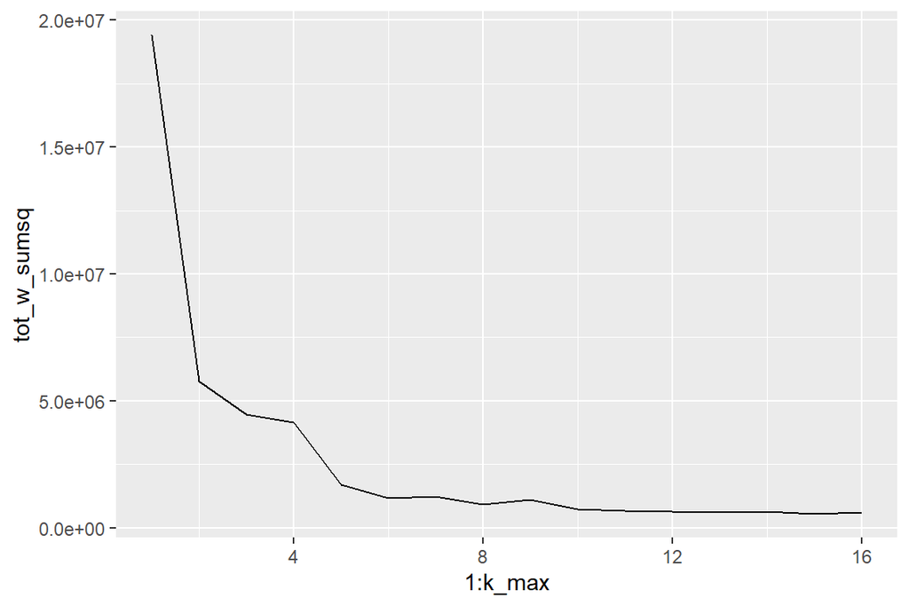

```r
library(ggplot2)
set.seed(1853) #Otherwise we get different clustering every time we run the code below.
k_max <- 16 #I increased this a little bit because I wanted it to see when it plateaued out.

# calculate the total within sum of squares
tot_w_sumsq <- sapply(1:k_max, function(k){kmeans(Boston, k)$tot.withinss})
qplot(x = 1:k_max, y = tot_w_sumsq , geom = 'line')
```

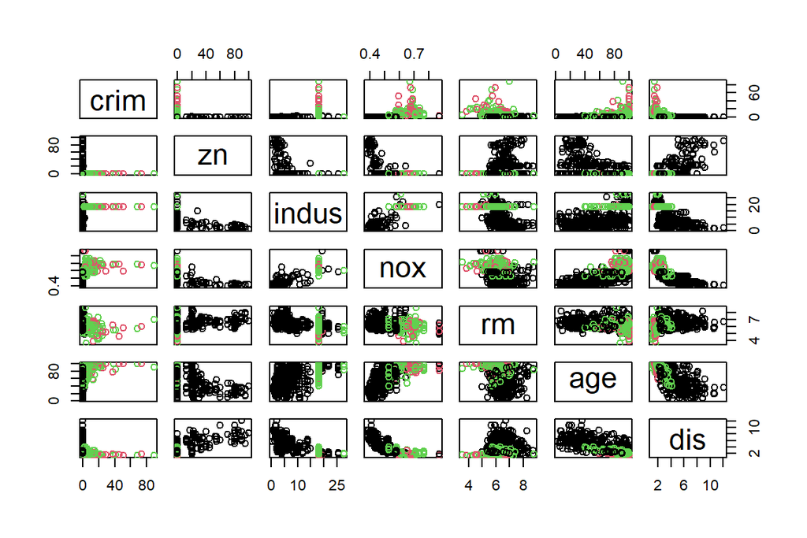

```r
#Either 3 or 5 clusters would be my choice in reduction in variance. After 8 its fairly flat, so there is no benefit in adding any more after that.

# k-means clustering with 4
km <- kmeans(Boston, centers = 3)

#I am going to split the dataframe into 2 bits, otherwise it is a little unruly.
pairs(Boston[1:7], col = km$cluster)
```

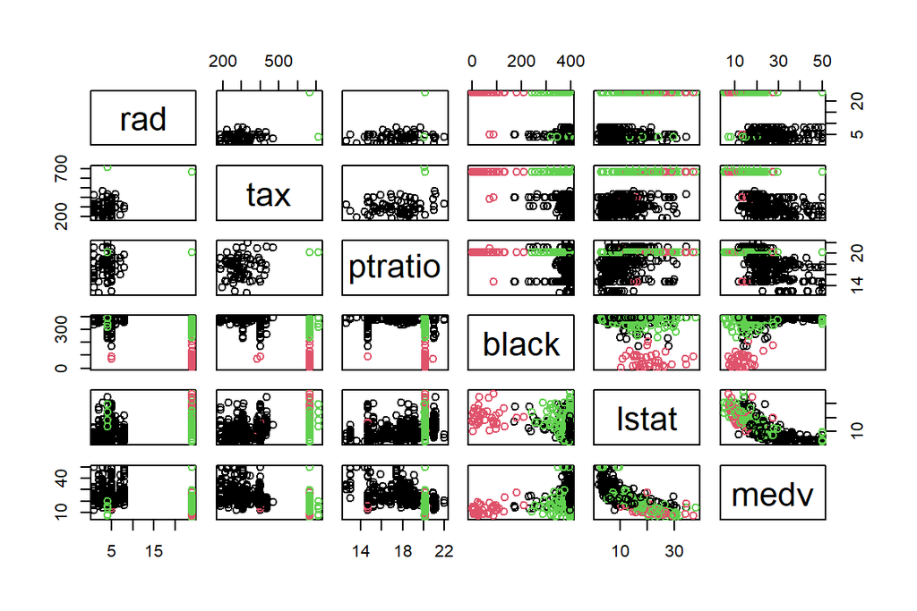

```r
pairs(Boston[8:13], col = km$cluster)
```

#### **Task 7 - Bonus**

Reload data and check that everything has been scaled and centred.

```r
str(Boston)
```

```
## 'data.frame':    506 obs. of  13 variables:
##  $ crim   : num  0.00632 0.02731 0.02729 0.03237 0.06905 ...
##  $ zn     : num  18 0 0 0 0 0 12.5 12.5 12.5 12.5 ...
##  $ indus  : num  2.31 7.07 7.07 2.18 2.18 2.18 7.87 7.87 7.87 7.87 ...
##  $ nox    : num  0.538 0.469 0.469 0.458 0.458 0.458 0.524 0.524 0.524 0.524 ...
##  $ rm     : num  6.58 6.42 7.18 7 7.15 ...
##  $ age    : num  65.2 78.9 61.1 45.8 54.2 58.7 66.6 96.1 100 85.9 ...
##  $ dis    : num  4.09 4.97 4.97 6.06 6.06 ...
##  $ rad    : int  1 2 2 3 3 3 5 5 5 5 ...
##  $ tax    : num  296 242 242 222 222 222 311 311 311 311 ...
##  $ ptratio: num  15.3 17.8 17.8 18.7 18.7 18.7 15.2 15.2 15.2 15.2 ...
##  $ black  : num  397 397 393 395 397 ...
##  $ lstat  : num  4.98 9.14 4.03 2.94 5.33 ...
##  $ medv   : num  24 21.6 34.7 33.4 36.2 28.7 22.9 27.1 16.5 18.9 ...
```

```r
boston_scaled=as.data.frame(scale(Boston,center=TRUE,scale=TRUE))
glimpse(boston_scaled)
```

```
## Rows: 506
## Columns: 13
## $ crim    <dbl> -0.4193669, -0.4169267, -0.4169290, -0.4163384, -0.4120741, -0…
## $ zn      <dbl> 0.28454827, -0.48724019, -0.48724019, -0.48724019, -0.48724019…
## $ indus   <dbl> -1.2866362, -0.5927944, -0.5927944, -1.3055857, -1.3055857, -1…
## $ nox     <dbl> -0.1440749, -0.7395304, -0.7395304, -0.8344581, -0.8344581, -0…
## $ rm      <dbl> 0.4132629, 0.1940824, 1.2814456, 1.0152978, 1.2273620, 0.20689…
## $ age     <dbl> -0.11989477, 0.36680343, -0.26554897, -0.80908783, -0.51067434…
## $ dis     <dbl> 0.1400749840, 0.5566090496, 0.5566090496, 1.0766711351, 1.0766…
## $ rad     <dbl> -0.9818712, -0.8670245, -0.8670245, -0.7521778, -0.7521778, -0…
## $ tax     <dbl> -0.6659492, -0.9863534, -0.9863534, -1.1050216, -1.1050216, -1…
## $ ptratio <dbl> -1.4575580, -0.3027945, -0.3027945, 0.1129203, 0.1129203, 0.11…
## $ black   <dbl> 0.4406159, 0.4406159, 0.3960351, 0.4157514, 0.4406159, 0.41016…
## $ lstat   <dbl> -1.07449897, -0.49195252, -1.20753241, -1.36017078, -1.0254866…
## $ medv    <dbl> 0.15952779, -0.10142392, 1.32293748, 1.18158864, 1.48603229, 0…
```

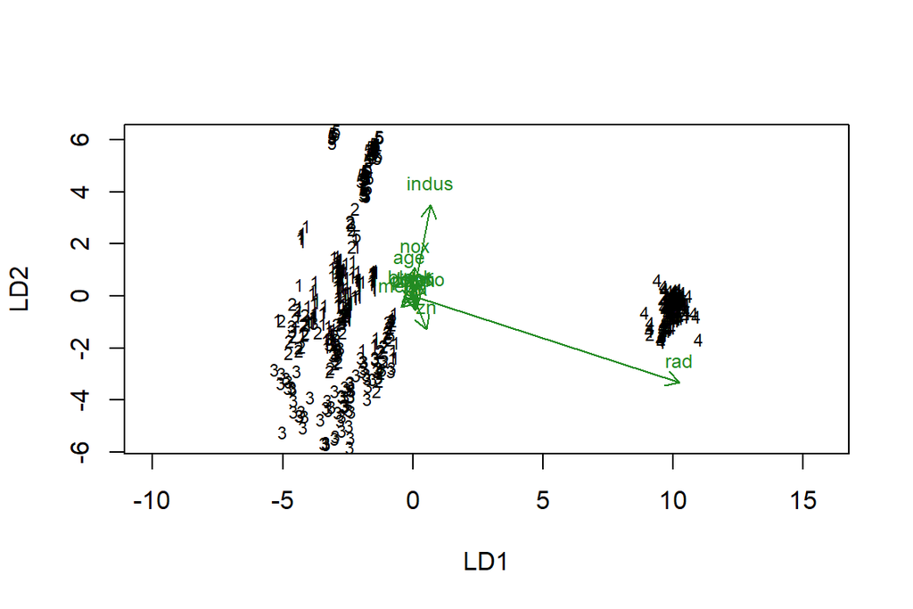

```r
set.seed(19885)
#I chose 5 clusters
km_1<-kmeans(boston_scaled,centers=5)

#This is to join it back onto the dataframe, so that its the right dimension
km1_cluster<-km_1$cluster
#Join
boston_scaled$cluster<-cbind(boston_scaled,km1_cluster)

#A bit awkward syntax, sorry! ran out of time to fix it
lda.boston <- lda(cluster$km1_cluster~., data = boston_scaled)

plot(lda.boston,dimen = 2)
lda.arrows(lda.boston, myscale = 2)
```

The most influential separators are accessibility to radial highways (rad), proportion of non-residential business areas (indus) and nitrogen oxide concentration (nox). Not sure what happened to property tax…? This was my hypothesis in Task 6, but this lda is run on standardised dataset, which maybe the cause in difference. But not 100% sure.

# Week 5 - Dimension reduction

### **Part 1 - Data manipulation**

I saved this file locally on my computer

```r
humandata<-read_csv("human_data_for_ex5.csv")
glimpse(humandata)
```

```
## Rows: 195
## Columns: 19
## $ hdi_rank          <dbl> 1, 2, 3, 4, 5, 6, 6, 8, 9, 9, 11, 12, 13, 14, 14, 16…
## $ Country           <chr> "Norway", "Australia", "Switzerland", "Denmark", "Ne…
## $ hdi               <dbl> 0.944, 0.935, 0.930, 0.923, 0.922, 0.916, 0.916, 0.9…
## $ life_exp          <dbl> 81.6, 82.4, 83.0, 80.2, 81.6, 80.9, 80.9, 79.1, 82.0…
## $ exp_edu           <dbl> 17.5, 20.2, 15.8, 18.7, 17.9, 16.5, 18.6, 16.5, 15.9…
## $ mean_edu          <dbl> 12.6, 13.0, 12.8, 12.7, 11.9, 13.1, 12.2, 12.9, 13.0…
## $ gni_per_cap       <dbl> 64992, 42261, 56431, 44025, 45435, 43919, 39568, 529…
## $ gni_diff_hdi      <dbl> 5, 17, 6, 11, 9, 11, 16, 3, 11, 23, -7, -2, -10, -1,…
## $ gii_rank          <dbl> 1, 2, 3, 4, 5, 6, 6, 8, 9, 9, 11, 12, 13, 14, 14, 16…
## $ gii               <dbl> 0.067, 0.110, 0.028, 0.048, 0.062, 0.041, 0.113, 0.2…
## $ mat_mort          <dbl> 4, 6, 6, 5, 6, 7, 9, 28, 11, 8, 6, NA, NA, 4, 8, 4, …
## $ ad_birth          <dbl> 7.8, 12.1, 1.9, 5.1, 6.2, 3.8, 8.2, 31.0, 14.5, 25.3…
## $ perc_parl         <dbl> 39.6, 30.5, 28.5, 38.0, 36.9, 36.9, 19.9, 19.4, 28.2…
## $ fem_sec           <dbl> 97.4, 94.3, 95.0, 95.5, 87.7, 96.3, 80.5, 95.1, 100.…
## $ male_sec          <dbl> 96.7, 94.6, 96.6, 96.6, 90.5, 97.0, 78.6, 94.8, 100.…
## $ fem_part          <dbl> 61.2, 58.8, 61.8, 58.7, 58.5, 53.6, 53.1, 56.3, 61.6…
## $ male_part         <dbl> 68.7, 71.8, 74.9, 66.4, 70.6, 66.4, 68.1, 68.9, 71.0…
## $ prop_secondary_ed <dbl> 1.0072389, 0.9968288, 0.9834369, 0.9886128, 0.969060…
## $ prop_labour       <dbl> 0.8908297, 0.8189415, 0.8251001, 0.8840361, 0.828611…
```

This is a global dataset including main economic and socio-demographic variables that is aimed at measuring gender inequality in the work force. There are 195 countries (rows in the dataset) and 19 columns. The below header shows the details of the columns in the dataset.

- *hdi_rank = HDI Rank*
- *hdi = Human Development Index (HDI)*
- *life_exp=Life Expectancy at Birth*
- *exp_edu=Expected Years of Education*
- *mean_edu=Mean Years of Education*
- *gni_per_cap=Gross National Income (GNI) per Capita*
- *gni_diff_hdi=GNI per Capita Rank Minus HDI Rank*
- *gii_rank=GII Rank*
- *gii=Gender Inequality Index (GII)*
- *mat_mort=Maternal Mortality Ratio*
- *ad_birth=Adolescent Birth Rate*
- *perc_parl=Percent Representation in Parliament*
- *fem_sec=Population with Secondary Education (Female)*
- *male_sec=Population with Secondary Education (Male)*
- *fem_part=Labour Force Participation Rate (Female)*
- *male_part=Labour Force Participation Rate (Male)*

```r
#Removing columns that aren't necessary
complete_fem<- dplyr::select(humandata, c( "Country", "fem_sec", "fem_part", "exp_edu", "life_exp", "gni_per_cap", "mat_mort", "ad_birth", "perc_parl"))

#Checking if there is NAs in the rows
complete.cases(complete_fem)
```

```
##   [1]  TRUE  TRUE  TRUE  TRUE  TRUE  TRUE  TRUE  TRUE  TRUE  TRUE  TRUE FALSE
##  [13] FALSE  TRUE  TRUE  TRUE  TRUE  TRUE  TRUE  TRUE  TRUE  TRUE  TRUE  TRUE
##  [25]  TRUE  TRUE  TRUE  TRUE  TRUE  TRUE FALSE  TRUE  TRUE FALSE  TRUE  TRUE
##  [37]  TRUE  TRUE  TRUE  TRUE  TRUE  TRUE  TRUE  TRUE  TRUE  TRUE  TRUE  TRUE
##  [49]  TRUE  TRUE  TRUE  TRUE  TRUE  TRUE  TRUE  TRUE  TRUE FALSE  TRUE FALSE
##  [61]  TRUE  TRUE  TRUE FALSE  TRUE  TRUE  TRUE  TRUE  TRUE  TRUE  TRUE  TRUE
##  [73]  TRUE  TRUE  TRUE  TRUE FALSE  TRUE FALSE  TRUE  TRUE  TRUE  TRUE  TRUE
##  [85]  TRUE  TRUE  TRUE  TRUE FALSE  TRUE  TRUE  TRUE  TRUE FALSE  TRUE  TRUE
##  [97]  TRUE FALSE  TRUE  TRUE  TRUE  TRUE  TRUE  TRUE  TRUE  TRUE  TRUE  TRUE
## [109] FALSE  TRUE  TRUE  TRUE FALSE FALSE  TRUE  TRUE  TRUE  TRUE  TRUE  TRUE
## [121]  TRUE FALSE FALSE  TRUE  TRUE  TRUE  TRUE  TRUE  TRUE  TRUE  TRUE  TRUE
## [133] FALSE  TRUE FALSE  TRUE FALSE FALSE  TRUE  TRUE FALSE  TRUE  TRUE FALSE
## [145]  TRUE  TRUE  TRUE  TRUE FALSE  TRUE  TRUE FALSE  TRUE FALSE  TRUE  TRUE
## [157] FALSE  TRUE FALSE  TRUE  TRUE  TRUE  TRUE  TRUE  TRUE  TRUE  TRUE FALSE
## [169] FALSE  TRUE  TRUE  TRUE  TRUE  TRUE  TRUE  TRUE  TRUE FALSE  TRUE  TRUE
## [181]  TRUE FALSE  TRUE  TRUE  TRUE FALSE  TRUE  TRUE  TRUE  TRUE  TRUE  TRUE
## [193]  TRUE  TRUE  TRUE
```

```r
#Removing rows that have at least one NA
complete_fem<-complete_fem[complete.cases(complete_fem),]

#Only keeping countries of the world (removing averaged regions)
#The last 7 rows are all related to regions so we remove them by identifying the rows counting from the bottom up.
last <- nrow(complete_fem) - 7
complete_fem<-complete_fem[1:last, ]
glimpse(complete_fem)
```

```
## Rows: 155
## Columns: 9
## $ Country     <chr> "Norway", "Australia", "Switzerland", "Denmark", "Netherla…
## $ fem_sec     <dbl> 97.4, 94.3, 95.0, 95.5, 87.7, 96.3, 80.5, 95.1, 100.0, 95.…
## $ fem_part    <dbl> 61.2, 58.8, 61.8, 58.7, 58.5, 53.6, 53.1, 56.3, 61.6, 62.0…
## $ exp_edu     <dbl> 17.5, 20.2, 15.8, 18.7, 17.9, 16.5, 18.6, 16.5, 15.9, 19.2…
## $ life_exp    <dbl> 81.6, 82.4, 83.0, 80.2, 81.6, 80.9, 80.9, 79.1, 82.0, 81.8…
## $ gni_per_cap <dbl> 64992, 42261, 56431, 44025, 45435, 43919, 39568, 52947, 42…
## $ mat_mort    <dbl> 4, 6, 6, 5, 6, 7, 9, 28, 11, 8, 6, 4, 8, 4, 27, 2, 11, 6, …
## $ ad_birth    <dbl> 7.8, 12.1, 1.9, 5.1, 6.2, 3.8, 8.2, 31.0, 14.5, 25.3, 6.0,…
## $ perc_parl   <dbl> 39.6, 30.5, 28.5, 38.0, 36.9, 36.9, 19.9, 19.4, 28.2, 31.4…
```